# What is Psychometrics? Psychometric Evaluation of (Intensive) Longitudinal Data

Leonie V.D.E. Vogelsmeier & Joran Jongerling

# General instructions

During this lab session, we will take you through the steps of assessing measurement invariance and adequacy of model fit for cross-sectional, panel, and intensive longitudinal data. Note that invariance assessment for intensive longitudinal data is still difficult and requires special software(packages). We have some code for you to perform Latent Markov Factor Analysis using the `lmfa` package at the end of this script. We are currently working on implementing the cross-classified factor analysis in R (using Stan in the background), but this is still work in progress. You can, however, already perform the analysis in MPlus (code can be found here: https://osf.io/f83km/ )

To answer the questions in this practice sheet:

1. Download the material under [Practice](https://github.com/LeonieVm/Psych_Ida).
2. Unzip the archive.

You will need the two **datasets** `Data_Cross_Panel` and `Data_ILD`, which are automatically in your global environment once you open the workspace `Workspace_IOPS.RData` via the load-workspace button or with the command `load("[Path on your computer]/Workspace_IOPS.RData")`

# 1 Preliminaries

If you have not already done so, use the `install.packages` function to install the packages `semTools` and `devtools` and via `devtools`, install the package `lmfa`. Important note: Please check if you have the package `igraph` installed. If yes, please remove it (e.g., under the panel “Packages”). We need an older version because of a recent bug.

```r
# Install the packages if you don't have them yet
install.packages("semTools")
install.packages("devtools")

# Trick to install older igraph version
require(devtools)
install_version("igraph", version = "1.3.0", repos = "http://cran.us.r-project.org")

# Continue installing lmfa
devtools::install_github("leonievm/lmfa")

# Trick if something fails with semTools:
detach("package:semTools", unload = TRUE)
detach("package:lavaan", unload = TRUE)
```

Then load the packages and the workspace.

```r
# Load packages
library(semTools)
library(devtools)
library(lmfa)

# Read the workspace we will need for this session
load("Workspace_IOPS.RData")

# Read data that is part of the ESM package
data("ESM")
```

# 2 Cross-Sectional Data

Use the `Data_Cross_Panel` data to answer the questions in this section. We start by defining a model. Subsequently, we assess invariance. Finally, we retrieve the reliability.

Note: for an explanation of the model syntax (including the different symbols), see https://lavaan.ugent.be/tutorial/cfa.html

Quick summary:

- Regression of Y on X: `Y ~ X`
- Variance of Y specified as: `Y ~~ Y`
- Covariance between X and Y: `X ~~ Y`
- Intercept given by: `X ~ 1`
- Loading of item on factor `F1 =~ X`

## 2.1 - Write syntax for the factor model for the cross-sectional data.

```r
CM_factor_T1 <- '

# Define the latent factors.
CM_1 =~ NA*T1_CM_01 +lambda1*T1_CM_01 + T1_CM_02 + T1_CM_03 + T1_CM_04 +
        T1_CM_05 + T1_CM_06 + T1_CM_07 + T1_CM_08

# Intercepts
T1_CM_01 ~ i1*1
T1_CM_02 ~ 1
T1_CM_03 ~ 1
T1_CM_04 ~ 1
T1_CM_05 ~ 1
T1_CM_06 ~ 1
T1_CM_07 ~ 1
T1_CM_08 ~ 1

# Unique Variances
T1_CM_01 ~~ T1_CM_01
T1_CM_02 ~~ T1_CM_02
T1_CM_03 ~~ T1_CM_03
T1_CM_04 ~~ T1_CM_04
T1_CM_05 ~~ T1_CM_05
T1_CM_06 ~~ T1_CM_06
T1_CM_07 ~~ T1_CM_07
T1_CM_08 ~~ T1_CM_08

# Latent Variable Means
CM_1 ~ 0*1

# Latent Variable Variances and Covariance
CM_1 ~~ 1*CM_1
'
```

## 2.2 - Use the `cfa` function to fit the model to the data and set the argument `mimic` equal to “mplus”.

```r
# Model fitting
fit_CM_T1 <- cfa(CM_factor_T1, data = Data_Cross_Panel, mimic = "mplus")
```

## 2.3 - Use the `summary` function. Does the model fit well to the data?

Guidelines:

Look at **CFI** (should be > .90), **RMSEA** (should be < .08), **SRMR** (should be < .08), and **chi-square** (should be non-significant).

- The CFI (Comparative Fit Index), RMSEA (Root Mean Squared Error of Approximation), and SRMR (Standardized Root Mean Squared Error) are Approximate Fit Indices. They do not correct for sampling variability, have no clear cut-offs for good fit, and assume multivariate normal data. They are more qualitative measures of fit.
  - CFI: Looks at the improvement in fit relative to the independence model which states that every variable has a mean and variance, but all are unrelated (correlations are all 0).
  - RMSEA: Tests for close fit between data (observed (co)variances) and model implied relations.
  - SRMR: Looks at the (mean) covariance residuals.
- Chi-square: Actual test with corresponding null-hypothesis. It tests for the null-hypothesis of perfect fit (in the population), that is, the model perfectly recovers the observed (co)variances, which might be a little unrealistic. It is (unnecessarily) strict (especially for large sample size), assumes multivariate normality, and assumes a random sample. Moreover, it doesn’t work well in case where there are high correlations and/or high percentages of unique variance. It also tends to miss misfit in single parameters (e.g., a single large covariance residual) and patterns of smaller misfit (many small residuals), AND a non-significant result does NOT mean a good model.

```r
# Getting the results
summary(fit_CM_T1, fit.measures = TRUE)
```

```
lavaan 0.6.15 ended normally after 16 iterations

  Estimator                                         ML
  Optimization method                           NLMINB
  Number of model parameters                        24

  Number of observations                           395
  Number of missing patterns                         1

Model Test User Model:

  Test statistic                                60.297
  Degrees of freedom                                20
  P-value (Chi-square)                           0.000

Model Test Baseline Model:

  Test statistic                               781.823
  Degrees of freedom                                28
  P-value                                        0.000

User Model versus Baseline Model:

  Comparative Fit Index (CFI)                    0.947
  Tucker-Lewis Index (TLI)                       0.925

  Robust Comparative Fit Index (CFI)             0.947
  Robust Tucker-Lewis Index (TLI)                0.925

Loglikelihood and Information Criteria:

  Loglikelihood user model (H0)              -3789.693
  Loglikelihood unrestricted model (H1)             NA

  Akaike (AIC)                                7627.385
  Bayesian (BIC)                              7722.878
  Sample-size adjusted Bayesian (SABIC)       7646.726

Root Mean Square Error of Approximation:

```

[output cut: 42 more lines]

```
   .T1_CM_07          6.028    0.045  134.648    0.000
   .T1_CM_08          5.324    0.051  103.542    0.000
    CM_1              0.000

Variances:
                   Estimate  Std.Err  z-value  P(>|z|)
   .T1_CM_01          0.226    0.027    8.240    0.000
   .T1_CM_02          0.708    0.054   13.195    0.000
   .T1_CM_03          0.587    0.046   12.833    0.000
   .T1_CM_04          0.519    0.041   12.649    0.000
   .T1_CM_05          0.433    0.033   13.179    0.000
   .T1_CM_06          0.584    0.048   12.159    0.000
   .T1_CM_07          0.461    0.038   12.027    0.000
   .T1_CM_08          0.847    0.063   13.410    0.000
    CM_1              1.000
```

The CFI is larger than .90 and the SRMR is smaller than .08. The point-estimate of the RMSEA is also smaller than .08, but the 95% confidence interval for this fit measure goes up all the way to .092. Finally, the chi-square test is significant. Normally, we would like at least three of the four indices to show good modelfit, but here only two of the indices do so, while a third indicates that modelfit is maybe ok. We therefore conclude that modelfit is sufficient but not good.

## 2.4 - Generate code for checking configural invariance between groups. Can you figure out what the `c(NA, NA)*T1_CM_0X` implies?

```r
# Generate code for checking configural invariance between groups
mod.configural  <- semTools::measEq.syntax(configural.model = CM_factor_T1,
                                         data = Data_Cross_Panel,
                                         group = "Gender", mimic = "mplus")

# Inspect the generated code
cat(as.character(mod.configural))
```

```
## LOADINGS:

CM_1 =~ c(NA, NA)*T1_CM_01 + c(lambda.1_1.g1, lambda.1_1.g2)*T1_CM_01
CM_1 =~ c(NA, NA)*T1_CM_02 + c(lambda.2_1.g1, lambda.2_1.g2)*T1_CM_02
CM_1 =~ c(NA, NA)*T1_CM_03 + c(lambda.3_1.g1, lambda.3_1.g2)*T1_CM_03
CM_1 =~ c(NA, NA)*T1_CM_04 + c(lambda.4_1.g1, lambda.4_1.g2)*T1_CM_04
CM_1 =~ c(NA, NA)*T1_CM_05 + c(lambda.5_1.g1, lambda.5_1.g2)*T1_CM_05
CM_1 =~ c(NA, NA)*T1_CM_06 + c(lambda.6_1.g1, lambda.6_1.g2)*T1_CM_06
CM_1 =~ c(NA, NA)*T1_CM_07 + c(lambda.7_1.g1, lambda.7_1.g2)*T1_CM_07
CM_1 =~ c(NA, NA)*T1_CM_08 + c(lambda.8_1.g1, lambda.8_1.g2)*T1_CM_08

## INTERCEPTS:

T1_CM_01 ~ c(NA, NA)*1 + c(nu.1.g1, nu.1.g2)*1
T1_CM_02 ~ c(NA, NA)*1 + c(nu.2.g1, nu.2.g2)*1
T1_CM_03 ~ c(NA, NA)*1 + c(nu.3.g1, nu.3.g2)*1
T1_CM_04 ~ c(NA, NA)*1 + c(nu.4.g1, nu.4.g2)*1
T1_CM_05 ~ c(NA, NA)*1 + c(nu.5.g1, nu.5.g2)*1
T1_CM_06 ~ c(NA, NA)*1 + c(nu.6.g1, nu.6.g2)*1
T1_CM_07 ~ c(NA, NA)*1 + c(nu.7.g1, nu.7.g2)*1
T1_CM_08 ~ c(NA, NA)*1 + c(nu.8.g1, nu.8.g2)*1

## UNIQUE-FACTOR VARIANCES:

T1_CM_01 ~~ c(NA, NA)*T1_CM_01 + c(theta.1_1.g1, theta.1_1.g2)*T1_CM_01
T1_CM_02 ~~ c(NA, NA)*T1_CM_02 + c(theta.2_2.g1, theta.2_2.g2)*T1_CM_02
T1_CM_03 ~~ c(NA, NA)*T1_CM_03 + c(theta.3_3.g1, theta.3_3.g2)*T1_CM_03
T1_CM_04 ~~ c(NA, NA)*T1_CM_04 + c(theta.4_4.g1, theta.4_4.g2)*T1_CM_04
T1_CM_05 ~~ c(NA, NA)*T1_CM_05 + c(theta.5_5.g1, theta.5_5.g2)*T1_CM_05
T1_CM_06 ~~ c(NA, NA)*T1_CM_06 + c(theta.6_6.g1, theta.6_6.g2)*T1_CM_06
T1_CM_07 ~~ c(NA, NA)*T1_CM_07 + c(theta.7_7.g1, theta.7_7.g2)*T1_CM_07
T1_CM_08 ~~ c(NA, NA)*T1_CM_08 + c(theta.8_8.g1, theta.8_8.g2)*T1_CM_08

## LATENT MEANS/INTERCEPTS:

CM_1 ~ c(0, 0)*1 + c(alpha.1.g1, alpha.1.g2)*1

## COMMON-FACTOR VARIANCES:

CM_1 ~~ c(1, 1)*CM_1 + c(psi.1_1.g1, psi.1_1.g2)*CM_1
```

As explained in the lavaan manual, ‘there is no need […] to set the factor loading of its first indicator[s per group] equal to one [because we already fix the factor variances to 1]. To force [the] factor loading[s] to be free, we pre-multiply it with NA, as a hint to lavaan that the value of this parameter is ‘missing’ and therefore still unknown.’

## 2.5 - Generate code for checking loading invariance between groups.

```r
# Generate code for checking invariance of loadings
mod.loadings  <- semTools::measEq.syntax(configural.model = CM_factor_T1,
                                           data = Data_Cross_Panel,
                                           group.equal = c("loadings"),
                                           group = "Gender", mimic = "mplus")

# Inspect the generated code
cat(as.character(mod.loadings))
```

```
## LOADINGS:

CM_1 =~ c(NA, NA)*T1_CM_01 + c(lambda.1_1, lambda.1_1)*T1_CM_01
CM_1 =~ c(NA, NA)*T1_CM_02 + c(lambda.2_1, lambda.2_1)*T1_CM_02
CM_1 =~ c(NA, NA)*T1_CM_03 + c(lambda.3_1, lambda.3_1)*T1_CM_03
CM_1 =~ c(NA, NA)*T1_CM_04 + c(lambda.4_1, lambda.4_1)*T1_CM_04
CM_1 =~ c(NA, NA)*T1_CM_05 + c(lambda.5_1, lambda.5_1)*T1_CM_05
CM_1 =~ c(NA, NA)*T1_CM_06 + c(lambda.6_1, lambda.6_1)*T1_CM_06
CM_1 =~ c(NA, NA)*T1_CM_07 + c(lambda.7_1, lambda.7_1)*T1_CM_07
CM_1 =~ c(NA, NA)*T1_CM_08 + c(lambda.8_1, lambda.8_1)*T1_CM_08

## INTERCEPTS:

T1_CM_01 ~ c(NA, NA)*1 + c(nu.1.g1, nu.1.g2)*1
T1_CM_02 ~ c(NA, NA)*1 + c(nu.2.g1, nu.2.g2)*1
T1_CM_03 ~ c(NA, NA)*1 + c(nu.3.g1, nu.3.g2)*1
T1_CM_04 ~ c(NA, NA)*1 + c(nu.4.g1, nu.4.g2)*1
T1_CM_05 ~ c(NA, NA)*1 + c(nu.5.g1, nu.5.g2)*1
T1_CM_06 ~ c(NA, NA)*1 + c(nu.6.g1, nu.6.g2)*1
T1_CM_07 ~ c(NA, NA)*1 + c(nu.7.g1, nu.7.g2)*1
T1_CM_08 ~ c(NA, NA)*1 + c(nu.8.g1, nu.8.g2)*1

## UNIQUE-FACTOR VARIANCES:

T1_CM_01 ~~ c(NA, NA)*T1_CM_01 + c(theta.1_1.g1, theta.1_1.g2)*T1_CM_01
T1_CM_02 ~~ c(NA, NA)*T1_CM_02 + c(theta.2_2.g1, theta.2_2.g2)*T1_CM_02
T1_CM_03 ~~ c(NA, NA)*T1_CM_03 + c(theta.3_3.g1, theta.3_3.g2)*T1_CM_03
T1_CM_04 ~~ c(NA, NA)*T1_CM_04 + c(theta.4_4.g1, theta.4_4.g2)*T1_CM_04
T1_CM_05 ~~ c(NA, NA)*T1_CM_05 + c(theta.5_5.g1, theta.5_5.g2)*T1_CM_05
T1_CM_06 ~~ c(NA, NA)*T1_CM_06 + c(theta.6_6.g1, theta.6_6.g2)*T1_CM_06
T1_CM_07 ~~ c(NA, NA)*T1_CM_07 + c(theta.7_7.g1, theta.7_7.g2)*T1_CM_07
T1_CM_08 ~~ c(NA, NA)*T1_CM_08 + c(theta.8_8.g1, theta.8_8.g2)*T1_CM_08

## LATENT MEANS/INTERCEPTS:

CM_1 ~ c(0, 0)*1 + c(alpha.1.g1, alpha.1.g2)*1

## COMMON-FACTOR VARIANCES:

CM_1 ~~ c(1, NA)*CM_1 + c(psi.1_1.g1, psi.1_1.g2)*CM_1
```

## 2.6 - Generate code for checking intercept invariance between groups.

```r
# Generate code for checking invariance of intercepts and loadings
mod.int.load <- semTools::measEq.syntax(configural.model = CM_factor_T1,
                                           data = Data_Cross_Panel,
                                           group.equal = c("intercepts",
                                                           "loadings"),
                                           group = "Gender", mimic = "mplus")

# Inspect the generated code
cat(as.character(mod.int.load))
```

```
## LOADINGS:

CM_1 =~ c(NA, NA)*T1_CM_01 + c(lambda.1_1, lambda.1_1)*T1_CM_01
CM_1 =~ c(NA, NA)*T1_CM_02 + c(lambda.2_1, lambda.2_1)*T1_CM_02
CM_1 =~ c(NA, NA)*T1_CM_03 + c(lambda.3_1, lambda.3_1)*T1_CM_03
CM_1 =~ c(NA, NA)*T1_CM_04 + c(lambda.4_1, lambda.4_1)*T1_CM_04
CM_1 =~ c(NA, NA)*T1_CM_05 + c(lambda.5_1, lambda.5_1)*T1_CM_05
CM_1 =~ c(NA, NA)*T1_CM_06 + c(lambda.6_1, lambda.6_1)*T1_CM_06
CM_1 =~ c(NA, NA)*T1_CM_07 + c(lambda.7_1, lambda.7_1)*T1_CM_07
CM_1 =~ c(NA, NA)*T1_CM_08 + c(lambda.8_1, lambda.8_1)*T1_CM_08

## INTERCEPTS:

T1_CM_01 ~ c(NA, NA)*1 + c(nu.1, nu.1)*1
T1_CM_02 ~ c(NA, NA)*1 + c(nu.2, nu.2)*1
T1_CM_03 ~ c(NA, NA)*1 + c(nu.3, nu.3)*1
T1_CM_04 ~ c(NA, NA)*1 + c(nu.4, nu.4)*1
T1_CM_05 ~ c(NA, NA)*1 + c(nu.5, nu.5)*1
T1_CM_06 ~ c(NA, NA)*1 + c(nu.6, nu.6)*1
T1_CM_07 ~ c(NA, NA)*1 + c(nu.7, nu.7)*1
T1_CM_08 ~ c(NA, NA)*1 + c(nu.8, nu.8)*1

## UNIQUE-FACTOR VARIANCES:

T1_CM_01 ~~ c(NA, NA)*T1_CM_01 + c(theta.1_1.g1, theta.1_1.g2)*T1_CM_01
T1_CM_02 ~~ c(NA, NA)*T1_CM_02 + c(theta.2_2.g1, theta.2_2.g2)*T1_CM_02
T1_CM_03 ~~ c(NA, NA)*T1_CM_03 + c(theta.3_3.g1, theta.3_3.g2)*T1_CM_03
T1_CM_04 ~~ c(NA, NA)*T1_CM_04 + c(theta.4_4.g1, theta.4_4.g2)*T1_CM_04
T1_CM_05 ~~ c(NA, NA)*T1_CM_05 + c(theta.5_5.g1, theta.5_5.g2)*T1_CM_05
T1_CM_06 ~~ c(NA, NA)*T1_CM_06 + c(theta.6_6.g1, theta.6_6.g2)*T1_CM_06
T1_CM_07 ~~ c(NA, NA)*T1_CM_07 + c(theta.7_7.g1, theta.7_7.g2)*T1_CM_07
T1_CM_08 ~~ c(NA, NA)*T1_CM_08 + c(theta.8_8.g1, theta.8_8.g2)*T1_CM_08

## LATENT MEANS/INTERCEPTS:

CM_1 ~ c(0, NA)*1 + c(alpha.1.g1, alpha.1.g2)*1

## COMMON-FACTOR VARIANCES:

CM_1 ~~ c(1, NA)*CM_1 + c(psi.1_1.g1, psi.1_1.g2)*CM_1
```

## 2.7 - Fit the three models to the data.

```r
# Fit the configural invariance model
fit.configural <- cfa(as.character(mod.configural), data = Data_Cross_Panel,
                      group = "Gender", mimic = "mplus")

# Fit the loading invariance model
fit.loadings <- cfa(as.character(mod.loadings), data = Data_Cross_Panel,
                    group = "Gender", mimic = "mplus")

# Fit the intercept and loading invariance model
fit.int.load <- cfa(as.character(mod.int.load), data = Data_Cross_Panel,
                    group = "Gender", mimic = "mplus")
```

## 2.8 - Does configural invariance hold?

```r
# Check model fit using CFI, RMSEA, SRMR, and Chi-square again
summary(fit.configural, fit.measures = TRUE)
```

```
lavaan 0.6.15 ended normally after 27 iterations

  Estimator                                         ML
  Optimization method                           NLMINB
  Number of model parameters                        48

  Number of observations per group:
    1                                               75
    2                                              320
  Number of missing patterns per group:
    1                                                1
    2                                                1

Model Test User Model:

  Test statistic                                82.346
  Degrees of freedom                                40
  P-value (Chi-square)                           0.000
  Test statistic for each group:
    1                                           23.329
    2                                           59.016

Model Test Baseline Model:

  Test statistic                               800.182
  Degrees of freedom                                56
  P-value                                        0.000

User Model versus Baseline Model:

  Comparative Fit Index (CFI)                    0.943
  Tucker-Lewis Index (TLI)                       0.920

  Robust Comparative Fit Index (CFI)             0.943
  Robust Tucker-Lewis Index (TLI)                0.920

Loglikelihood and Information Criteria:

  Loglikelihood user model (H0)              -3766.211
  Loglikelihood unrestricted model (H1)             NA
```

[output cut: 91 more lines]

```
   .T1_CM_0 (n.7.)    6.066    0.049  122.853    0.000
   .T1_CM_0 (n.8.)    5.369    0.057   94.503    0.000
    CM_1    (a.1.)    0.000

Variances:
                   Estimate  Std.Err  z-value  P(>|z|)
   .T1_CM_0 (t.1_)    0.239    0.031    7.606    0.000
   .T1_CM_0 (t.2_)    0.694    0.058   11.977    0.000
   .T1_CM_0 (t.3_)    0.517    0.047   11.095    0.000
   .T1_CM_0 (t.4_)    0.494    0.043   11.454    0.000
   .T1_CM_0 (t.5_)    0.394    0.033   11.938    0.000
   .T1_CM_0 (t.6_)    0.593    0.055   10.835    0.000
   .T1_CM_0 (t.7_)    0.477    0.044   10.914    0.000
   .T1_CM_0 (t.8_)    0.845    0.070   12.050    0.000
    CM_1    (p.1_)    1.000
```

Yes, configural invariance holds because the CFI is larger than .90 and the SRMR is smaller than .08. The point-estimate of the RMSEA is also smaller than .08, but again the 95% confidence interval for this fit measure does include the value of .08 (and higher, up to .096). Finally, the chi-square test is significant. We therefore conclude that modelfit of the configural invariance model is sufficient.

## 2.9 - Now compare the different models successively, using the guidelines below.

- More than 20 observations per group: Change should not be larger than -.01 for **CFI**, 0.015 for **RMSEA**, and 0.03 for **SRMR** (*loading invariance*) or .015 for **SRMR** (*intercept invariance*). Difference in chi-square should be non-significant
- 10-20 observations per group: All as above but: Change should not be larger than -.02 for **CFI** and 0.03 **RMSEA** for *loading invariance*.
- Less than 10 observations per group: Invariance testing is not a good idea.

## 2.10 - Does loading invariance hold?

```r
Check.Load <- semTools::compareFit(fit.configural, fit.loadings)
summary(Check.Load)
```

```
################### Nested Model Comparison #########################

Chi-Squared Difference Test

               Df    AIC    BIC  Chisq Chisq diff RMSEA Df diff Pr(>Chisq)
fit.configural 40 7628.4 7819.4 82.346
fit.loadings   47 7620.6 7783.7 88.528     6.1825     0       7     0.5186

####################### Model Fit Indices ###########################
                 chisq df pvalue rmsea   cfi   tli  srmr       aic       bic
fit.configural 82.346† 40   .000 .073  .943  .920  .048† 7628.423  7819.409
fit.loadings   88.528  47   .000 .067† .944† .934† .067  7620.605† 7783.739†

################## Differences in Fit Indices #######################
                              df  rmsea   cfi   tli  srmr    aic    bic
fit.loadings - fit.configural  7 -0.006 0.001 0.013 0.018 -7.818 -35.67
```

Yes, loading invariance holds because the chi-square difference test between the configural model and the model with fixed loadings across groups is non-significant. In addition, the change in CFI, RMSEA, and SRMR are .001, -.006, and .018 respectively. This is all within the guidelines specified above. Importantly, we also see that the model with fixed loadings has adequate fit to the data since the CFI is larger than .90, and the RMSEA and SRMR are both smaller than .08. If the fit of the model with fixed loadings had been insufficient, you should not conclude that there is loading invariance even if the differences with the configural model are all within the boundaries specified above.

## 2.11 - Does intercept invariance hold?

```r
Check.Int <- semTools::compareFit(fit.loadings, fit.int.load)
summary(Check.Int)
```

```
################### Nested Model Comparison #########################

Chi-Squared Difference Test

             Df    AIC    BIC   Chisq Chisq diff    RMSEA Df diff Pr(>Chisq)
fit.loadings 47 7620.6 7783.7  88.528
fit.int.load 54 7622.7 7758.0 104.622     16.094 0.081103       7    0.02427 *
---
Signif. codes:  0 '***' 0.001 '**' 0.01 '*' 0.05 '.' 0.1 ' ' 1

####################### Model Fit Indices ###########################
                chisq df pvalue rmsea   cfi   tli  srmr       aic       bic
fit.loadings  88.528† 47   .000 .067† .944† .934† .067† 7620.605† 7783.739
fit.int.load 104.622  54   .000 .069  .932  .929  .079  7622.699  7757.981†

################## Differences in Fit Indices #######################
                            df rmsea    cfi    tli  srmr   aic     bic
fit.int.load - fit.loadings  7 0.002 -0.012 -0.004 0.013 2.094 -25.759
```

No, intercept invariance does not hold because the chi-square difference test is significant and the change in CFI is larger than .01. The changes in RMSEA and SRMR are okay, but two out of the four measures indicate that fixing intercepts acorss groups leads to significantly worse fit.

## 2.12 - Check the differences in intercepts across groups. Which difference is the largest?

```r
# Difference in groups in intercepts
parameterEstimates(fit.loadings)[9:16,7] -
  parameterEstimates(fit.loadings)[35:42,7]
```

```
[1] -0.22520833 -0.35479167 -0.07062500 -0.23125000 -0.35958333 -0.01895833 -0.19895833 -0.23541667
```

```r
which(
  (parameterEstimates(fit.loadings)[9:16,7] -
     parameterEstimates(fit.loadings)[35:42,7])
  == min(parameterEstimates(fit.loadings)[9:16,7] -
           parameterEstimates(fit.loadings)[35:42,7]))
```

```
[1] 5
```

The largest difference is in the intercept of item 5. Note that the indices in the code above are specific for this factor model. If you have a different model, you need to use different indices.

## 2.13 - Adjust the model by allowing for partial non-invariance of item 5 and fit it to the data.

```r
mod.intercepts.part <- semTools::measEq.syntax(configural.model= CM_factor_T1,
                                          data = Data_Cross_Panel,
                                          group.equal = c("loadings",
                                                          "intercepts"),
                                          group.partial = c("T1_CM_05 ~ 1"),
                                          group ="Gender", mimic = "mplus")

# Inspect the generated code
cat(as.character(mod.intercepts.part))
```

```
## LOADINGS:

CM_1 =~ c(NA, NA)*T1_CM_01 + c(lambda.1_1, lambda.1_1)*T1_CM_01
CM_1 =~ c(NA, NA)*T1_CM_02 + c(lambda.2_1, lambda.2_1)*T1_CM_02
CM_1 =~ c(NA, NA)*T1_CM_03 + c(lambda.3_1, lambda.3_1)*T1_CM_03
CM_1 =~ c(NA, NA)*T1_CM_04 + c(lambda.4_1, lambda.4_1)*T1_CM_04
CM_1 =~ c(NA, NA)*T1_CM_05 + c(lambda.5_1, lambda.5_1)*T1_CM_05
CM_1 =~ c(NA, NA)*T1_CM_06 + c(lambda.6_1, lambda.6_1)*T1_CM_06
CM_1 =~ c(NA, NA)*T1_CM_07 + c(lambda.7_1, lambda.7_1)*T1_CM_07
CM_1 =~ c(NA, NA)*T1_CM_08 + c(lambda.8_1, lambda.8_1)*T1_CM_08

## INTERCEPTS:

T1_CM_01 ~ c(NA, NA)*1 + c(nu.1, nu.1)*1
T1_CM_02 ~ c(NA, NA)*1 + c(nu.2, nu.2)*1
T1_CM_03 ~ c(NA, NA)*1 + c(nu.3, nu.3)*1
T1_CM_04 ~ c(NA, NA)*1 + c(nu.4, nu.4)*1
T1_CM_05 ~ c(NA, NA)*1 + c(nu.5.g1, nu.5.g2)*1
T1_CM_06 ~ c(NA, NA)*1 + c(nu.6, nu.6)*1
T1_CM_07 ~ c(NA, NA)*1 + c(nu.7, nu.7)*1
T1_CM_08 ~ c(NA, NA)*1 + c(nu.8, nu.8)*1

## UNIQUE-FACTOR VARIANCES:

T1_CM_01 ~~ c(NA, NA)*T1_CM_01 + c(theta.1_1.g1, theta.1_1.g2)*T1_CM_01
T1_CM_02 ~~ c(NA, NA)*T1_CM_02 + c(theta.2_2.g1, theta.2_2.g2)*T1_CM_02
T1_CM_03 ~~ c(NA, NA)*T1_CM_03 + c(theta.3_3.g1, theta.3_3.g2)*T1_CM_03
T1_CM_04 ~~ c(NA, NA)*T1_CM_04 + c(theta.4_4.g1, theta.4_4.g2)*T1_CM_04
T1_CM_05 ~~ c(NA, NA)*T1_CM_05 + c(theta.5_5.g1, theta.5_5.g2)*T1_CM_05
T1_CM_06 ~~ c(NA, NA)*T1_CM_06 + c(theta.6_6.g1, theta.6_6.g2)*T1_CM_06
T1_CM_07 ~~ c(NA, NA)*T1_CM_07 + c(theta.7_7.g1, theta.7_7.g2)*T1_CM_07
T1_CM_08 ~~ c(NA, NA)*T1_CM_08 + c(theta.8_8.g1, theta.8_8.g2)*T1_CM_08

## LATENT MEANS/INTERCEPTS:

CM_1 ~ c(0, NA)*1 + c(alpha.1.g1, alpha.1.g2)*1

## COMMON-FACTOR VARIANCES:

CM_1 ~~ c(1, NA)*CM_1 + c(psi.1_1.g1, psi.1_1.g2)*CM_1
```

```r
# Fit the intercept invariance model
fit.intercepts.part <- cfa(as.character(mod.intercepts.part), data = Data_Cross_Panel,
                      group ="Gender", mimic = "mplus")
```

## 2.14 - Does partial intercept invariance hold?

```r
Check.Int.Part <- semTools::compareFit(fit.loadings, fit.intercepts.part)
summary(Check.Int.Part)
```

```
################### Nested Model Comparison #########################

Chi-Squared Difference Test

                    Df    AIC    BIC  Chisq Chisq diff   RMSEA Df diff Pr(>Chisq)
fit.loadings        47 7620.6 7783.7 88.528
fit.intercepts.part 53 7618.0 7757.3 97.954     9.4261 0.05377       6      0.151

####################### Model Fit Indices ###########################
                      chisq df pvalue rmsea   cfi   tli  srmr       aic       bic
fit.loadings        88.528† 47   .000 .067  .944† .934  .067† 7620.605  7783.739
fit.intercepts.part 97.954  53   .000 .066† .940  .936† .075  7618.031† 7757.292†

################## Differences in Fit Indices #######################
                                   df  rmsea    cfi   tli  srmr    aic     bic
fit.intercepts.part - fit.loadings  6 -0.001 -0.005 0.003 0.009 -2.574 -26.447
```

Yes, now the model does not fit significantly worse than the model with fixed loadings. The chi-square difference test is non-significant, and the changes in the CFI, RMSEA and SRMR after fixing the intercepts of all items except item 5 are smaller than .01, .015, and .015 respectively. In addition, the model with fixed loadings and intercept also has sufficient fit to the data. Partial intercept invariance therefore holds.

## 2.15 - What is the reliability per group for the final model? It is sufficient?

```r
# Calculate Reliability for the final model
compRelSEM(fit.intercepts.part)
```

| group | CM_1 |
| --- | --- |
| 1 | 0.8018731 |
| 2 | 0.7953991 |

The reliability for group 1 is equal to `0.802` and the reliability for group 2 is equal to `0.795`. Thus, the reliability is okay.

# 3 Panel Data

## 3.1 - Write syntax for the factor model for the panel data.

```r
LI_CM <- '

# Define the latent factors.
CM_1 =~ NA*T1_CM_01 + 1*T1_CM_01 + T1_CM_02 + T1_CM_03 + T1_CM_04 + T1_CM_05
+ T1_CM_06 + T1_CM_07 + T1_CM_08

CM_2 =~ NA*T2_CM_01 + 1*T2_CM_01 + T2_CM_02 + T2_CM_03 + T2_CM_04 + T2_CM_05
+ T2_CM_06 + T2_CM_07 + T2_CM_08

CM_3 =~ NA*T3_CM_01 + 1*T3_CM_01 + T3_CM_02 + T3_CM_03 + T3_CM_04 + T3_CM_05
+ T3_CM_06 + T3_CM_07 + T3_CM_08

# Intercepts
T1_CM_01 ~ 1
T1_CM_02 ~ 1
T1_CM_03 ~ 1
T1_CM_04 ~ 1
T1_CM_05 ~ 1
T1_CM_06 ~ 1
T1_CM_07 ~ 1
T1_CM_08 ~ 1

T2_CM_01 ~ 1
T2_CM_02 ~ 1
T2_CM_03 ~ 1
T2_CM_04 ~ 1
T2_CM_05 ~ 1
T2_CM_06 ~ 1
T2_CM_07 ~ 1
T2_CM_08 ~ 1

T3_CM_01 ~ 1
T3_CM_02 ~ 1
T3_CM_03 ~ 1
T3_CM_04 ~ 1
T3_CM_05 ~ 1
T3_CM_06 ~ 1
T3_CM_07 ~ 1
T3_CM_08 ~ 1

# Unique Variances
T1_CM_01 ~~ T1_CM_01
T1_CM_02 ~~ T1_CM_02
T1_CM_03 ~~ T1_CM_03
T1_CM_04 ~~ T1_CM_04
T1_CM_05 ~~ T1_CM_05
T1_CM_06 ~~ T1_CM_06
T1_CM_07 ~~ T1_CM_07
T1_CM_08 ~~ T1_CM_08

T2_CM_01 ~~ T2_CM_01
T2_CM_02 ~~ T2_CM_02
T2_CM_03 ~~ T2_CM_03
T2_CM_04 ~~ T2_CM_04
T2_CM_05 ~~ T2_CM_05
T2_CM_06 ~~ T2_CM_06
T2_CM_07 ~~ T2_CM_07
T2_CM_08 ~~ T2_CM_08

T3_CM_01 ~~ T3_CM_01
T3_CM_02 ~~ T3_CM_02
T3_CM_03 ~~ T3_CM_03
T3_CM_04 ~~ T3_CM_04
T3_CM_05 ~~ T3_CM_05
T3_CM_06 ~~ T3_CM_06
T3_CM_07 ~~ T3_CM_07
T3_CM_08 ~~ T3_CM_08

# Latent Variable Means
CM_1 ~ 0*1
CM_2 ~ 0*1
CM_3 ~ 0*1

# Latent Variable Variances and Covariance
CM_1 ~~ 1*CM_1
CM_2 ~~ 1*CM_2
CM_3 ~~ 1*CM_3
'
```

## 3.2 - Use the `cfa` function to fit the model to the data and set the argument `mimic` equal to “mplus”.

```r
# Model fitting
fit_CM_Long <- cfa(LI_CM, data = Data_Cross_Panel, mimic = "mplus")
```

## 3.3 - Use the `summary` function. Does the model fit well to the data?

Guidelines:

Look at **CFI** (should be > .90), **RMSEA** (should be < .08), **SRMR** (should be < .08), and **chi-square** (should be non-significant).

- The CFI (Comparative Fit Index), RMSEA (Root Mean Squared Error of Approximation), and SRMR (Standardized Root Mean Squared Error) are Approximate Fit Indices. They do not correct for sampling variability, have no clear cut-offs for good fit, and assume multivariate normal data. They are more qualitative measures of fit.
  - CFI: Looks at the improvement in fit relative to the independence model which states that every variable has a mean and variance, but all are unrelated (correlations are all 0).
  - RMSEA: Tests for close fit between data (observed (co)variances) and model implied relations.
  - SRMR: Looks at the (mean) covariance residuals.
- Chi-square: Actual test with corresponding null-hypothesis. It tests for the null-hypothesis of perfect fit (in the population), that is, the model perfectly recovers the observed (co)variances, which might be a little unrealistic. It is (unnecessarily) strict (especially for large sample size), assumes multivariate normality, and assumes a random sample. Moreover, it doesn’t work well in case where there are high correlations and/or high percentages of unique variance. It also tends to miss misfit in single parameters (e.g., a single large covariance residual) and patterns of smaller misfit (many small residuals), AND a non-significant result does NOT mean a good model.

```r
# Getting the results
summary(fit_CM_Long, fit.measures = TRUE)
```

```
lavaan 0.6.15 ended normally after 24 iterations

  Estimator                                         ML
  Optimization method                           NLMINB
  Number of model parameters                        75

  Number of observations                           395
  Number of missing patterns                         1

Model Test User Model:

  Test statistic                              1759.210
  Degrees of freedom                               249
  P-value (Chi-square)                           0.000

Model Test Baseline Model:

  Test statistic                              4304.760
  Degrees of freedom                               276
  P-value                                        0.000

User Model versus Baseline Model:

  Comparative Fit Index (CFI)                    0.625
  Tucker-Lewis Index (TLI)                       0.584

  Robust Comparative Fit Index (CFI)             0.625
  Robust Tucker-Lewis Index (TLI)                0.584

Loglikelihood and Information Criteria:

  Loglikelihood user model (H0)             -11825.071
  Loglikelihood unrestricted model (H1)             NA

  Akaike (AIC)                               23800.141
  Bayesian (BIC)                             24098.558
  Sample-size adjusted Bayesian (SABIC)      23860.582

Root Mean Square Error of Approximation:

```

[output cut: 104 more lines]

```
   .T2_CM_05          0.512    0.040   12.765    0.000
   .T2_CM_06          0.532    0.043   12.350    0.000
   .T2_CM_07          0.583    0.046   12.615    0.000
   .T2_CM_08          0.960    0.071   13.541    0.000
   .T3_CM_01          0.316    0.034    9.289    0.000
   .T3_CM_02          0.757    0.057   13.177    0.000
   .T3_CM_03          0.581    0.051   11.411    0.000
   .T3_CM_04          0.796    0.060   13.293    0.000
   .T3_CM_05          0.662    0.049   13.465    0.000
   .T3_CM_06          0.824    0.064   12.890    0.000
   .T3_CM_07          0.545    0.043   12.571    0.000
   .T3_CM_08          1.598    0.117   13.681    0.000
    CM_1              1.000
    CM_2              1.000
    CM_3              1.000
```

The fit of the model to the data is bad. The Chi-square test is significant, the CFI is too low, and the RMSEA and SRMR are both too high. Possible reason for the misfit could have to do with the nature of the data. We have repeated measures here and scores on one time-point are likely related to scores on a successive time-point, and possibly above and beyond the dependence that is already there through the correlated factors at T1, T2, and T3. If you’re bad at multiple-choice questions at T1 for example, you probably still are at T2 and T3. That is why you often see correlations added between the same items at different (usually succesive) time-points in models for panel data. When using the code below to test for longitudinal invariance, these correlations are automatically added to the model so we won’t add them here. Do see if you can spot these serial correlations in the generated code below however.

## 3.4 - Generate code for checking configural invariance across time.

```r
# Generate code for checking configural invariance across time

longFacNames <- list(CM = c("CM_1","CM_2","CM_3"))

mod.configural.long <-semTools::measEq.syntax(LI_CM,
                                     longFacNames = longFacNames,
                                     data = Data_Cross_Panel, missing = "fiml")
# Now we use a new argument longFacNames. For details, see ?measEq.syntax

# Inspect the generated code
cat(as.character(mod.configural.long))
```

```
## LOADINGS:

CM_1 =~ NA*T1_CM_01 + lambda.1_1*T1_CM_01
CM_1 =~ NA*T1_CM_02 + lambda.2_1*T1_CM_02
CM_1 =~ NA*T1_CM_03 + lambda.3_1*T1_CM_03
CM_1 =~ NA*T1_CM_04 + lambda.4_1*T1_CM_04
CM_1 =~ NA*T1_CM_05 + lambda.5_1*T1_CM_05
CM_1 =~ NA*T1_CM_06 + lambda.6_1*T1_CM_06
CM_1 =~ NA*T1_CM_07 + lambda.7_1*T1_CM_07
CM_1 =~ NA*T1_CM_08 + lambda.8_1*T1_CM_08
CM_2 =~ NA*T2_CM_01 + lambda.9_2*T2_CM_01
CM_2 =~ NA*T2_CM_02 + lambda.10_2*T2_CM_02
CM_2 =~ NA*T2_CM_03 + lambda.11_2*T2_CM_03
CM_2 =~ NA*T2_CM_04 + lambda.12_2*T2_CM_04
CM_2 =~ NA*T2_CM_05 + lambda.13_2*T2_CM_05
CM_2 =~ NA*T2_CM_06 + lambda.14_2*T2_CM_06
CM_2 =~ NA*T2_CM_07 + lambda.15_2*T2_CM_07
CM_2 =~ NA*T2_CM_08 + lambda.16_2*T2_CM_08
CM_3 =~ NA*T3_CM_01 + lambda.17_3*T3_CM_01
CM_3 =~ NA*T3_CM_02 + lambda.18_3*T3_CM_02
CM_3 =~ NA*T3_CM_03 + lambda.19_3*T3_CM_03
CM_3 =~ NA*T3_CM_04 + lambda.20_3*T3_CM_04
CM_3 =~ NA*T3_CM_05 + lambda.21_3*T3_CM_05
CM_3 =~ NA*T3_CM_06 + lambda.22_3*T3_CM_06
CM_3 =~ NA*T3_CM_07 + lambda.23_3*T3_CM_07
CM_3 =~ NA*T3_CM_08 + lambda.24_3*T3_CM_08

## INTERCEPTS:

T1_CM_01 ~ NA*1 + nu.1*1
T1_CM_02 ~ NA*1 + nu.2*1
T1_CM_03 ~ NA*1 + nu.3*1
T1_CM_04 ~ NA*1 + nu.4*1
T1_CM_05 ~ NA*1 + nu.5*1
T1_CM_06 ~ NA*1 + nu.6*1
T1_CM_07 ~ NA*1 + nu.7*1
T1_CM_08 ~ NA*1 + nu.8*1
T2_CM_01 ~ NA*1 + nu.9*1
T2_CM_02 ~ NA*1 + nu.10*1
T2_CM_03 ~ NA*1 + nu.11*1
```

[output cut: 70 more lines]

```
CM_1 ~ 0*1 + alpha.1*1
CM_2 ~ 0*1 + alpha.2*1
CM_3 ~ 0*1 + alpha.3*1

## COMMON-FACTOR VARIANCES:

CM_1 ~~ 1*CM_1 + psi.1_1*CM_1
CM_2 ~~ 1*CM_2 + psi.2_2*CM_2
CM_3 ~~ 1*CM_3 + psi.3_3*CM_3

## COMMON-FACTOR COVARIANCES:

CM_1 ~~ NA*CM_2 + psi.2_1*CM_2
CM_1 ~~ NA*CM_3 + psi.3_1*CM_3
CM_2 ~~ NA*CM_3 + psi.3_2*CM_3
```

## 3.5 - Fit the configural invariance model to the data.

```r
fit.configural.long <- lavaan::cfa(as.character(mod.configural.long),
                              data = Data_Cross_Panel,
                              fixed.x = FALSE)
```

## 3.6 - Does configural invariance hold?

```r
# Check model fit using CFI, RMSEA, SRMR, and Chi-square again
summary(fit.configural.long, fit.measures = TRUE)
```

```
lavaan 0.6.15 ended normally after 41 iterations

  Estimator                                         ML
  Optimization method                           NLMINB
  Number of model parameters                        99

  Number of observations                           395

Model Test User Model:

  Test statistic                               886.681
  Degrees of freedom                               225
  P-value (Chi-square)                           0.000

Model Test Baseline Model:

  Test statistic                              4304.760
  Degrees of freedom                               276
  P-value                                        0.000

User Model versus Baseline Model:

  Comparative Fit Index (CFI)                    0.836
  Tucker-Lewis Index (TLI)                       0.799

Loglikelihood and Information Criteria:

  Loglikelihood user model (H0)             -11388.806
  Loglikelihood unrestricted model (H1)             NA

  Akaike (AIC)                               22975.612
  Bayesian (BIC)                             23369.522
  Sample-size adjusted Bayesian (SABIC)      23055.394

Root Mean Square Error of Approximation:

  RMSEA                                          0.086
  90 Percent confidence interval - lower         0.080
  90 Percent confidence interval - upper         0.092
  P-value H_0: RMSEA <= 0.050                    0.000
```

[output cut: 134 more lines]

```
   .T2_CM_0 (t.13)    0.521    0.041   12.765    0.000
   .T2_CM_0 (t.14)    0.520    0.043   12.106    0.000
   .T2_CM_0 (t.15)    0.574    0.046   12.395    0.000
   .T2_CM_0 (t.16)    0.978    0.072   13.609    0.000
   .T3_CM_0 (t.17)    0.272    0.032    8.400    0.000
   .T3_CM_0 (t.18)    0.788    0.058   13.505    0.000
   .T3_CM_0 (t.19)    0.536    0.047   11.440    0.000
   .T3_CM_0 (t.20)    0.794    0.060   13.127    0.000
   .T3_CM_0 (t.21)    0.681    0.050   13.605    0.000
   .T3_CM_0 (t.22)    0.827    0.064   13.012    0.000
   .T3_CM_0 (t.23)    0.556    0.043   12.817    0.000
   .T3_CM_0 (t.24)    1.640    0.119   13.776    0.000
    CM_1    (p.1_)    1.000
    CM_2    (p.2_)    1.000
    CM_3    (p.3_)    1.000
```

The fit is not great because while the SRMR is lower than its recommended value, all other indices indicate a lack of fit (despite serial correlations between the same item at succesive time-points now being part of the model). This shows that at (at least) one of the three time-points the model fits less well. We just have to figure out exactly what part of the model does not fit well, and at what time-point(s). We’ll try to figure this out below using modification indices

## 3.7 - Check the modification indices. For each time-point separaterly, which residual covariances would be worth adding?

```r
# Obtain the modification indices
MIs <- modindices(fit.configural.long)

# Show the first 30
head(MIs[order(MIs$mi, decreasing = TRUE), 1:4], n = 30)
```

|  | lhs | op | rhs | mi |
| --- | --- | --- | --- | --- |
| 242 | T1_CM_05 | ~~ | T3_CM_01 | 41.55776 |
| 149 | CM_3 | =~ | T2_CM_04 | 30.73897 |
| 387 | T3_CM_02 | ~~ | T3_CM_05 | 29.12859 |
| 379 | T3_CM_01 | ~~ | T3_CM_03 | 25.76948 |
| 337 | T2_CM_04 | ~~ | T3_CM_01 | 23.10704 |
| 356 | T2_CM_06 | ~~ | T3_CM_01 | 21.48206 |
| 245 | T1_CM_05 | ~~ | T3_CM_04 | 19.52205 |
| 403 | T3_CM_06 | ~~ | T3_CM_07 | 19.51780 |
| 133 | CM_2 | =~ | T3_CM_04 | 18.52295 |
| 378 | T3_CM_01 | ~~ | T3_CM_02 | 18.21221 |

[output cut: 20 more lines]

At T3 items 2 and 5, and 1 and 3 are pretty correlated (`T3_CM_02 ~~ T3_CM_05`, `T3_CM_01 ~~ T3_CM_03`). At T2 items 1 and 2, and 3 and 6 are pretty correlated (`T2_CM_01 ~~ T2_CM_02`, `T2_CM_03 ~~ T2_CM_06`). At T1 items 4 and 5, and 3 and 6 are pretty correlated (`T1_CM_04 ~~ T1_CM_05`, `T1_CM_03 ~~ T1_CM_06`). We see that the residual correlation between items 3 and 6 is a suggested modification at both T1 and T2. Since we’re measuring the same construct at all three time-points, making similar adjustments at each time-point is preferred. We therefore choose to add the residual correlation between items 3 and 6 at T1, T2, and T3.

## 3.8 - Add one residual covariance per time-point to the model.

```r
LI_CM2 <- '

# Define the latent factors.
CM_1 =~ NA*T1_CM_01 + 1*T1_CM_01 + T1_CM_02 + T1_CM_03 + T1_CM_04 + T1_CM_05 + T1_CM_06 + T1_CM_07 + T1_CM_08
CM_2 =~ NA*T2_CM_01 + 1*T2_CM_01 + T2_CM_02 + T2_CM_03 + T2_CM_04 + T2_CM_05 + T2_CM_06 + T2_CM_07 + T2_CM_08
CM_3 =~ NA*T3_CM_01 + 1*T3_CM_01 + T3_CM_02 + T3_CM_03 + T3_CM_04 + T3_CM_05 + T3_CM_06 + T3_CM_07 + T3_CM_08

# Intercepts
T1_CM_01 ~ 1
T1_CM_02 ~ 1
T1_CM_03 ~ 1
T1_CM_04 ~ 1
T1_CM_05 ~ 1
T1_CM_06 ~ 1
T1_CM_07 ~ 1
T1_CM_08 ~ 1

T2_CM_01 ~ 1
T2_CM_02 ~ 1
T2_CM_03 ~ 1
T2_CM_04 ~ 1
T2_CM_05 ~ 1
T2_CM_06 ~ 1
T2_CM_07 ~ 1
T2_CM_08 ~ 1

T3_CM_01 ~ 1
T3_CM_02 ~ 1
T3_CM_03 ~ 1
T3_CM_04 ~ 1
T3_CM_05 ~ 1
T3_CM_06 ~ 1
T3_CM_07 ~ 1
T3_CM_08 ~ 1

# Unique Variances
T1_CM_01 ~~ T1_CM_01
T1_CM_02 ~~ T1_CM_02
T1_CM_03 ~~ T1_CM_03
T1_CM_04 ~~ T1_CM_04
T1_CM_05 ~~ T1_CM_05
T1_CM_06 ~~ T1_CM_06
T1_CM_07 ~~ T1_CM_07
T1_CM_08 ~~ T1_CM_08

T2_CM_01 ~~ T2_CM_01
T2_CM_02 ~~ T2_CM_02
T2_CM_03 ~~ T2_CM_03
T2_CM_04 ~~ T2_CM_04
T2_CM_05 ~~ T2_CM_05
T2_CM_06 ~~ T2_CM_06
T2_CM_07 ~~ T2_CM_07
T2_CM_08 ~~ T2_CM_08

T3_CM_01 ~~ T3_CM_01
T3_CM_02 ~~ T3_CM_02
T3_CM_03 ~~ T3_CM_03
T3_CM_04 ~~ T3_CM_04
T3_CM_05 ~~ T3_CM_05
T3_CM_06 ~~ T3_CM_06
T3_CM_07 ~~ T3_CM_07
T3_CM_08 ~~ T3_CM_08

# Latent Variable Means
CM_1 ~ 0*1
CM_2 ~ 0*1
CM_3 ~ 0*1

# Latent Variable Variances and Covariance
CM_1 ~~ 1*CM_1
CM_2 ~~ 1*CM_2
CM_3 ~~ 1*CM_3


# Residual Covariances
T1_CM_03 ~~ T1_CM_06
T2_CM_03 ~~ T2_CM_06
T3_CM_03 ~~ T3_CM_06
'
```

## 3.9 - Fit the adjusted model to the data.

```r
# Generate code and inspect it
mod.configural.long2 <-semTools::measEq.syntax(LI_CM2,
                                              longFacNames = longFacNames,
                                              data = Data_Cross_Panel, missing = "fiml")
cat(as.character(mod.configural.long2))
```

```
## LOADINGS:

CM_1 =~ NA*T1_CM_01 + lambda.1_1*T1_CM_01
CM_1 =~ NA*T1_CM_02 + lambda.2_1*T1_CM_02
CM_1 =~ NA*T1_CM_03 + lambda.3_1*T1_CM_03
CM_1 =~ NA*T1_CM_04 + lambda.4_1*T1_CM_04
CM_1 =~ NA*T1_CM_05 + lambda.5_1*T1_CM_05
CM_1 =~ NA*T1_CM_06 + lambda.6_1*T1_CM_06
CM_1 =~ NA*T1_CM_07 + lambda.7_1*T1_CM_07
CM_1 =~ NA*T1_CM_08 + lambda.8_1*T1_CM_08
CM_2 =~ NA*T2_CM_01 + lambda.9_2*T2_CM_01
CM_2 =~ NA*T2_CM_02 + lambda.10_2*T2_CM_02
CM_2 =~ NA*T2_CM_03 + lambda.11_2*T2_CM_03
CM_2 =~ NA*T2_CM_04 + lambda.12_2*T2_CM_04
CM_2 =~ NA*T2_CM_05 + lambda.13_2*T2_CM_05
CM_2 =~ NA*T2_CM_06 + lambda.14_2*T2_CM_06
CM_2 =~ NA*T2_CM_07 + lambda.15_2*T2_CM_07
CM_2 =~ NA*T2_CM_08 + lambda.16_2*T2_CM_08
CM_3 =~ NA*T3_CM_01 + lambda.17_3*T3_CM_01
CM_3 =~ NA*T3_CM_02 + lambda.18_3*T3_CM_02
CM_3 =~ NA*T3_CM_03 + lambda.19_3*T3_CM_03
CM_3 =~ NA*T3_CM_04 + lambda.20_3*T3_CM_04
CM_3 =~ NA*T3_CM_05 + lambda.21_3*T3_CM_05
CM_3 =~ NA*T3_CM_06 + lambda.22_3*T3_CM_06
CM_3 =~ NA*T3_CM_07 + lambda.23_3*T3_CM_07
CM_3 =~ NA*T3_CM_08 + lambda.24_3*T3_CM_08

## INTERCEPTS:

T1_CM_01 ~ NA*1 + nu.1*1
T1_CM_02 ~ NA*1 + nu.2*1
T1_CM_03 ~ NA*1 + nu.3*1
T1_CM_04 ~ NA*1 + nu.4*1
T1_CM_05 ~ NA*1 + nu.5*1
T1_CM_06 ~ NA*1 + nu.6*1
T1_CM_07 ~ NA*1 + nu.7*1
T1_CM_08 ~ NA*1 + nu.8*1
T2_CM_01 ~ NA*1 + nu.9*1
T2_CM_02 ~ NA*1 + nu.10*1
T2_CM_03 ~ NA*1 + nu.11*1
```

[output cut: 73 more lines]

```
CM_1 ~ 0*1 + alpha.1*1
CM_2 ~ 0*1 + alpha.2*1
CM_3 ~ 0*1 + alpha.3*1

## COMMON-FACTOR VARIANCES:

CM_1 ~~ 1*CM_1 + psi.1_1*CM_1
CM_2 ~~ 1*CM_2 + psi.2_2*CM_2
CM_3 ~~ 1*CM_3 + psi.3_3*CM_3

## COMMON-FACTOR COVARIANCES:

CM_1 ~~ NA*CM_2 + psi.2_1*CM_2
CM_1 ~~ NA*CM_3 + psi.3_1*CM_3
CM_2 ~~ NA*CM_3 + psi.3_2*CM_3
```

```r
# Model fitting
fit.configural.long2 <- lavaan::cfa(as.character(mod.configural.long2),
                              data = Data_Cross_Panel,
                              fixed.x = FALSE)
```

## 3.10 - Does configural invariance hold with the added residual variances?

```r
# Check model fit using CFI, RMSEA, SRMR, and Chi-square again
summary(fit.configural.long2, fit.measures = TRUE)
```

```
lavaan 0.6.15 ended normally after 40 iterations

  Estimator                                         ML
  Optimization method                           NLMINB
  Number of model parameters                       102

  Number of observations                           395

Model Test User Model:

  Test statistic                               851.227
  Degrees of freedom                               222
  P-value (Chi-square)                           0.000

Model Test Baseline Model:

  Test statistic                              4304.760
  Degrees of freedom                               276
  P-value                                        0.000

User Model versus Baseline Model:

  Comparative Fit Index (CFI)                    0.844
  Tucker-Lewis Index (TLI)                       0.806

Loglikelihood and Information Criteria:

  Loglikelihood user model (H0)             -11371.079
  Loglikelihood unrestricted model (H1)             NA

  Akaike (AIC)                               22946.158
  Bayesian (BIC)                             23352.005
  Sample-size adjusted Bayesian (SABIC)      23028.358

Root Mean Square Error of Approximation:

  RMSEA                                          0.085
  90 Percent confidence interval - lower         0.079
  90 Percent confidence interval - upper         0.091
  P-value H_0: RMSEA <= 0.050                    0.000
```

[output cut: 138 more lines]

```
   .T2_CM_0 (t.13)    0.513    0.041   12.640    0.000
   .T2_CM_0 (t.14)    0.534    0.043   12.304    0.000
   .T2_CM_0 (t.15)    0.564    0.046   12.253    0.000
   .T2_CM_0 (t.16)    0.977    0.072   13.591    0.000
   .T3_CM_0 (t.17)    0.271    0.034    8.048    0.000
   .T3_CM_0 (t.18)    0.782    0.058   13.460    0.000
   .T3_CM_0 (t.19)    0.565    0.049   11.598    0.000
   .T3_CM_0 (t.20)    0.788    0.060   13.060    0.000
   .T3_CM_0 (t.21)    0.674    0.050   13.560    0.000
   .T3_CM_0 (t.22)    0.875    0.067   13.077    0.000
   .T3_CM_0 (t.23)    0.542    0.043   12.653    0.000
   .T3_CM_0 (t.24)    1.645    0.119   13.772    0.000
    CM_1    (p.1_)    1.000
    CM_2    (p.2_)    1.000
    CM_3    (p.3_)    1.000
```

The fit is still not great because, apart from the SRMR, all fit indices are still indicating model misfit. We will therefore make some further alterations based on the modification indices. Note that you should always be very careful with the post-hoc model adjustments based on modification indices. Any alteration needs to make substantive sense, and purely adjusting your model based on fit indices means the risk of overfitting your model to the current sample, instead of finding a proper general model that also applies to (hypothetical) future samples from the same population.

## 3.11 - Check the modification indices. For each time-point separaterly, which residual covariances would be worth adding?

```r
# Obtain the modification indices
MIs2 <- modindices(fit.configural.long2)

# Show the first 30
head(MIs2[order(MIs2$mi, decreasing = TRUE), 1:4], n = 30)
```

|  | lhs | op | rhs | mi |
| --- | --- | --- | --- | --- |
| 380 | T3_CM_01 | ~~ | T3_CM_03 | 39.75533 |
| 244 | T1_CM_05 | ~~ | T3_CM_01 | 38.59858 |
| 152 | CM_3 | =~ | T2_CM_04 | 31.88575 |
| 388 | T3_CM_02 | ~~ | T3_CM_05 | 28.09554 |
| 338 | T2_CM_04 | ~~ | T3_CM_01 | 24.80208 |
| 379 | T3_CM_01 | ~~ | T3_CM_02 | 23.98326 |
| 357 | T2_CM_06 | ~~ | T3_CM_01 | 21.87404 |
| 247 | T1_CM_05 | ~~ | T3_CM_04 | 20.34611 |
| 136 | CM_2 | =~ | T3_CM_04 | 19.16089 |
| 195 | T1_CM_02 | ~~ | T3_CM_06 | 17.95353 |

[output cut: 20 more lines]

## 3.12 - Add one additional residual covariance per time-point to the model.

```r
LI_CM3 <- '

# Define the latent factors.
CM_1 =~ NA*T1_CM_01 + 1*T1_CM_01 + T1_CM_02 + T1_CM_03 + T1_CM_04 + T1_CM_05
+ T1_CM_06 + T1_CM_07 + T1_CM_08
CM_2 =~ NA*T2_CM_01 + 1*T2_CM_01 + T2_CM_02 + T2_CM_03 + T2_CM_04 + T2_CM_05
+ T2_CM_06 + T2_CM_07 + T2_CM_08
CM_3 =~ NA*T3_CM_01 + 1*T3_CM_01 + T3_CM_02 + T3_CM_03 + T3_CM_04 + T3_CM_05
+ T3_CM_06 + T3_CM_07 + T3_CM_08

# Intercepts
T1_CM_01 ~ 1
T1_CM_02 ~ 1
T1_CM_03 ~ 1
T1_CM_04 ~ 1
T1_CM_05 ~ 1
T1_CM_06 ~ 1
T1_CM_07 ~ 1
T1_CM_08 ~ 1

T2_CM_01 ~ 1
T2_CM_02 ~ 1
T2_CM_03 ~ 1
T2_CM_04 ~ 1
T2_CM_05 ~ 1
T2_CM_06 ~ 1
T2_CM_07 ~ 1
T2_CM_08 ~ 1

T3_CM_01 ~ 1
T3_CM_02 ~ 1
T3_CM_03 ~ 1
T3_CM_04 ~ 1
T3_CM_05 ~ 1
T3_CM_06 ~ 1
T3_CM_07 ~ 1
T3_CM_08 ~ 1

# Unique Variances
T1_CM_01 ~~ T1_CM_01
T1_CM_02 ~~ T1_CM_02
T1_CM_03 ~~ T1_CM_03
T1_CM_04 ~~ T1_CM_04
T1_CM_05 ~~ T1_CM_05
T1_CM_06 ~~ T1_CM_06
T1_CM_07 ~~ T1_CM_07
T1_CM_08 ~~ T1_CM_08

T2_CM_01 ~~ T2_CM_01
T2_CM_02 ~~ T2_CM_02
T2_CM_03 ~~ T2_CM_03
T2_CM_04 ~~ T2_CM_04
T2_CM_05 ~~ T2_CM_05
T2_CM_06 ~~ T2_CM_06
T2_CM_07 ~~ T2_CM_07
T2_CM_08 ~~ T2_CM_08

T3_CM_01 ~~ T3_CM_01
T3_CM_02 ~~ T3_CM_02
T3_CM_03 ~~ T3_CM_03
T3_CM_04 ~~ T3_CM_04
T3_CM_05 ~~ T3_CM_05
T3_CM_06 ~~ T3_CM_06
T3_CM_07 ~~ T3_CM_07
T3_CM_08 ~~ T3_CM_08

# Latent Variable Means
CM_1 ~ 0*1
CM_2 ~ 0*1
CM_3 ~ 0*1

# Latent Variable Variances and Covariance
CM_1 ~~ 1*CM_1
CM_2 ~~ 1*CM_2
CM_3 ~~ 1*CM_3


# Residual Covariances
T1_CM_03 ~~ T1_CM_06
T2_CM_03 ~~ T2_CM_06
T3_CM_03 ~~ T3_CM_06

T1_CM_01 ~~ T1_CM_02
T2_CM_01 ~~ T2_CM_02
T3_CM_01 ~~ T3_CM_02

'
```

## 3.13 - Fit the adjusted model to the data.

```r
# Generate code and inspect it
mod.configural.long3 <-semTools::measEq.syntax(LI_CM3,
                                               longFacNames = longFacNames,
                                               data = Data_Cross_Panel, missing = "fiml")
cat(as.character(mod.configural.long3))
```

```
## LOADINGS:

CM_1 =~ NA*T1_CM_01 + lambda.1_1*T1_CM_01
CM_1 =~ NA*T1_CM_02 + lambda.2_1*T1_CM_02
CM_1 =~ NA*T1_CM_03 + lambda.3_1*T1_CM_03
CM_1 =~ NA*T1_CM_04 + lambda.4_1*T1_CM_04
CM_1 =~ NA*T1_CM_05 + lambda.5_1*T1_CM_05
CM_1 =~ NA*T1_CM_06 + lambda.6_1*T1_CM_06
CM_1 =~ NA*T1_CM_07 + lambda.7_1*T1_CM_07
CM_1 =~ NA*T1_CM_08 + lambda.8_1*T1_CM_08
CM_2 =~ NA*T2_CM_01 + lambda.9_2*T2_CM_01
CM_2 =~ NA*T2_CM_02 + lambda.10_2*T2_CM_02
CM_2 =~ NA*T2_CM_03 + lambda.11_2*T2_CM_03
CM_2 =~ NA*T2_CM_04 + lambda.12_2*T2_CM_04
CM_2 =~ NA*T2_CM_05 + lambda.13_2*T2_CM_05
CM_2 =~ NA*T2_CM_06 + lambda.14_2*T2_CM_06
CM_2 =~ NA*T2_CM_07 + lambda.15_2*T2_CM_07
CM_2 =~ NA*T2_CM_08 + lambda.16_2*T2_CM_08
CM_3 =~ NA*T3_CM_01 + lambda.17_3*T3_CM_01
CM_3 =~ NA*T3_CM_02 + lambda.18_3*T3_CM_02
CM_3 =~ NA*T3_CM_03 + lambda.19_3*T3_CM_03
CM_3 =~ NA*T3_CM_04 + lambda.20_3*T3_CM_04
CM_3 =~ NA*T3_CM_05 + lambda.21_3*T3_CM_05
CM_3 =~ NA*T3_CM_06 + lambda.22_3*T3_CM_06
CM_3 =~ NA*T3_CM_07 + lambda.23_3*T3_CM_07
CM_3 =~ NA*T3_CM_08 + lambda.24_3*T3_CM_08

## INTERCEPTS:

T1_CM_01 ~ NA*1 + nu.1*1
T1_CM_02 ~ NA*1 + nu.2*1
T1_CM_03 ~ NA*1 + nu.3*1
T1_CM_04 ~ NA*1 + nu.4*1
T1_CM_05 ~ NA*1 + nu.5*1
T1_CM_06 ~ NA*1 + nu.6*1
T1_CM_07 ~ NA*1 + nu.7*1
T1_CM_08 ~ NA*1 + nu.8*1
T2_CM_01 ~ NA*1 + nu.9*1
T2_CM_02 ~ NA*1 + nu.10*1
T2_CM_03 ~ NA*1 + nu.11*1
```

[output cut: 76 more lines]

```
CM_1 ~ 0*1 + alpha.1*1
CM_2 ~ 0*1 + alpha.2*1
CM_3 ~ 0*1 + alpha.3*1

## COMMON-FACTOR VARIANCES:

CM_1 ~~ 1*CM_1 + psi.1_1*CM_1
CM_2 ~~ 1*CM_2 + psi.2_2*CM_2
CM_3 ~~ 1*CM_3 + psi.3_3*CM_3

## COMMON-FACTOR COVARIANCES:

CM_1 ~~ NA*CM_2 + psi.2_1*CM_2
CM_1 ~~ NA*CM_3 + psi.3_1*CM_3
CM_2 ~~ NA*CM_3 + psi.3_2*CM_3
```

```r
# Model fitting
fit.configural.long3 <- lavaan::cfa(as.character(mod.configural.long3),
                               data = Data_Cross_Panel,
                               fixed.x = FALSE)
```

## 3.14 - Does configural invariance hold with the additional added residual variances?

```r
# Check model fit using CFI, RMSEA, SRMR, and Chi-square again
summary(fit.configural.long3, fit.measures = TRUE)
```

```
lavaan 0.6.15 ended normally after 42 iterations

  Estimator                                         ML
  Optimization method                           NLMINB
  Number of model parameters                       105

  Number of observations                           395

Model Test User Model:

  Test statistic                               805.962
  Degrees of freedom                               219
  P-value (Chi-square)                           0.000

Model Test Baseline Model:

  Test statistic                              4304.760
  Degrees of freedom                               276
  P-value                                        0.000

User Model versus Baseline Model:

  Comparative Fit Index (CFI)                    0.854
  Tucker-Lewis Index (TLI)                       0.816

Loglikelihood and Information Criteria:

  Loglikelihood user model (H0)             -11348.447
  Loglikelihood unrestricted model (H1)             NA

  Akaike (AIC)                               22906.893
  Bayesian (BIC)                             23324.676
  Sample-size adjusted Bayesian (SABIC)      22991.511

Root Mean Square Error of Approximation:

  RMSEA                                          0.082
  90 Percent confidence interval - lower         0.076
  90 Percent confidence interval - upper         0.089
  P-value H_0: RMSEA <= 0.050                    0.000
```

[output cut: 142 more lines]

```
   .T2_CM_0 (t.13)    0.520    0.040   12.839    0.000
   .T2_CM_0 (t.14)    0.531    0.043   12.497    0.000
   .T2_CM_0 (t.15)    0.583    0.046   12.599    0.000
   .T2_CM_0 (t.16)    0.977    0.072   13.662    0.000
   .T3_CM_0 (t.17)    0.231    0.034    6.762    0.000
   .T3_CM_0 (t.18)    0.699    0.056   12.438    0.000
   .T3_CM_0 (t.19)    0.607    0.049   12.368    0.000
   .T3_CM_0 (t.20)    0.807    0.061   13.323    0.000
   .T3_CM_0 (t.21)    0.662    0.048   13.672    0.000
   .T3_CM_0 (t.22)    0.899    0.067   13.432    0.000
   .T3_CM_0 (t.23)    0.553    0.042   13.025    0.000
   .T3_CM_0 (t.24)    1.630    0.118   13.833    0.000
    CM_1    (p.1_)    1.000
    CM_2    (p.2_)    1.000
    CM_3    (p.3_)    1.000
```

The fit is still not good enough, even after adding additional residual correlations. Looking at the modification indices you might have noticed however that items 3, 1, and 6 are always the ones causing ‘problems’. We will therefore remove these items one at a time, but the same caution we made above with adding covariances based on modification indices apply here! Model modifications should ideally not be based on statistics alone and researchers always want to be careful when removing items as this might change the interpretation and/or scope of the latent variable being modeled.

## 3.15 - Remove item 3 from the original model (i.e., without any added residual covariances).

```r
LI_CM4 <- '

# Define the latent factors.
CM_1 =~ NA*T1_CM_01 + 1*T1_CM_01 + T1_CM_02 + T1_CM_04 + T1_CM_05 + T1_CM_06
+ T1_CM_07 + T1_CM_08
CM_2 =~ NA*T2_CM_01 + 1*T2_CM_01 + T2_CM_02 + T2_CM_04 + T2_CM_05 + T2_CM_06
+ T2_CM_07 + T2_CM_08
CM_3 =~ NA*T3_CM_01 + 1*T3_CM_01 + T3_CM_02 + T3_CM_04 + T3_CM_05 + T3_CM_06
+ T3_CM_07 + T3_CM_08

# Intercepts
T1_CM_01 ~ 1
T1_CM_02 ~ 1
T1_CM_04 ~ 1
T1_CM_05 ~ 1
T1_CM_06 ~ 1
T1_CM_07 ~ 1
T1_CM_08 ~ 1

T2_CM_01 ~ 1
T2_CM_02 ~ 1
T2_CM_04 ~ 1
T2_CM_05 ~ 1
T2_CM_06 ~ 1
T2_CM_07 ~ 1
T2_CM_08 ~ 1

T3_CM_01 ~ 1
T3_CM_02 ~ 1
T3_CM_04 ~ 1
T3_CM_05 ~ 1
T3_CM_06 ~ 1
T3_CM_07 ~ 1
T3_CM_08 ~ 1

# Unique Variances
T1_CM_01 ~~ T1_CM_01
T1_CM_02 ~~ T1_CM_02
T1_CM_04 ~~ T1_CM_04
T1_CM_05 ~~ T1_CM_05
T1_CM_06 ~~ T1_CM_06
T1_CM_07 ~~ T1_CM_07
T1_CM_08 ~~ T1_CM_08

T2_CM_01 ~~ T2_CM_01
T2_CM_02 ~~ T2_CM_02
T2_CM_04 ~~ T2_CM_04
T2_CM_05 ~~ T2_CM_05
T2_CM_06 ~~ T2_CM_06
T2_CM_07 ~~ T2_CM_07
T2_CM_08 ~~ T2_CM_08

T3_CM_01 ~~ T3_CM_01
T3_CM_02 ~~ T3_CM_02
T3_CM_04 ~~ T3_CM_04
T3_CM_05 ~~ T3_CM_05
T3_CM_06 ~~ T3_CM_06
T3_CM_07 ~~ T3_CM_07
T3_CM_08 ~~ T3_CM_08

# Latent Variable Means
CM_1 ~ 0*1
CM_2 ~ 0*1
CM_3 ~ 0*1

# Latent Variable Variances and Covariance
CM_1 ~~ 1*CM_1
CM_2 ~~ 1*CM_2
CM_3 ~~ 1*CM_3
'
```

## 3.16 - Fit the adjusted model to the data.

```r
# Generate code and inspect it
mod.configural.long4 <- semTools::measEq.syntax(LI_CM4,
                                               longFacNames = longFacNames,
                                               data = Data_Cross_Panel, missing = "fiml")
cat(as.character(mod.configural.long4))
```

```
## LOADINGS:

CM_1 =~ NA*T1_CM_01 + lambda.1_1*T1_CM_01
CM_1 =~ NA*T1_CM_02 + lambda.2_1*T1_CM_02
CM_1 =~ NA*T1_CM_04 + lambda.3_1*T1_CM_04
CM_1 =~ NA*T1_CM_05 + lambda.4_1*T1_CM_05
CM_1 =~ NA*T1_CM_06 + lambda.5_1*T1_CM_06
CM_1 =~ NA*T1_CM_07 + lambda.6_1*T1_CM_07
CM_1 =~ NA*T1_CM_08 + lambda.7_1*T1_CM_08
CM_2 =~ NA*T2_CM_01 + lambda.8_2*T2_CM_01
CM_2 =~ NA*T2_CM_02 + lambda.9_2*T2_CM_02
CM_2 =~ NA*T2_CM_04 + lambda.10_2*T2_CM_04
CM_2 =~ NA*T2_CM_05 + lambda.11_2*T2_CM_05
CM_2 =~ NA*T2_CM_06 + lambda.12_2*T2_CM_06
CM_2 =~ NA*T2_CM_07 + lambda.13_2*T2_CM_07
CM_2 =~ NA*T2_CM_08 + lambda.14_2*T2_CM_08
CM_3 =~ NA*T3_CM_01 + lambda.15_3*T3_CM_01
CM_3 =~ NA*T3_CM_02 + lambda.16_3*T3_CM_02
CM_3 =~ NA*T3_CM_04 + lambda.17_3*T3_CM_04
CM_3 =~ NA*T3_CM_05 + lambda.18_3*T3_CM_05
CM_3 =~ NA*T3_CM_06 + lambda.19_3*T3_CM_06
CM_3 =~ NA*T3_CM_07 + lambda.20_3*T3_CM_07
CM_3 =~ NA*T3_CM_08 + lambda.21_3*T3_CM_08

## INTERCEPTS:

T1_CM_01 ~ NA*1 + nu.1*1
T1_CM_02 ~ NA*1 + nu.2*1
T1_CM_04 ~ NA*1 + nu.3*1
T1_CM_05 ~ NA*1 + nu.4*1
T1_CM_06 ~ NA*1 + nu.5*1
T1_CM_07 ~ NA*1 + nu.6*1
T1_CM_08 ~ NA*1 + nu.7*1
T2_CM_01 ~ NA*1 + nu.8*1
T2_CM_02 ~ NA*1 + nu.9*1
T2_CM_04 ~ NA*1 + nu.10*1
T2_CM_05 ~ NA*1 + nu.11*1
T2_CM_06 ~ NA*1 + nu.12*1
T2_CM_07 ~ NA*1 + nu.13*1
T2_CM_08 ~ NA*1 + nu.14*1
```

[output cut: 58 more lines]

```
CM_1 ~ 0*1 + alpha.1*1
CM_2 ~ 0*1 + alpha.2*1
CM_3 ~ 0*1 + alpha.3*1

## COMMON-FACTOR VARIANCES:

CM_1 ~~ 1*CM_1 + psi.1_1*CM_1
CM_2 ~~ 1*CM_2 + psi.2_2*CM_2
CM_3 ~~ 1*CM_3 + psi.3_3*CM_3

## COMMON-FACTOR COVARIANCES:

CM_1 ~~ NA*CM_2 + psi.2_1*CM_2
CM_1 ~~ NA*CM_3 + psi.3_1*CM_3
CM_2 ~~ NA*CM_3 + psi.3_2*CM_3
```

```r
# Model fitting
fit.configural.long4 <- lavaan::cfa(as.character(mod.configural.long4),
                               data = Data_Cross_Panel,
                               fixed.x = FALSE)
```

## 3.17 - Does configural invariance hold after removing item 3?

```r
# Check model fit using CFI, RMSEA, SRMR, and Chi-square again
summary(fit.configural.long4, fit.measures=T)
```

```
lavaan 0.6.15 ended normally after 43 iterations

  Estimator                                         ML
  Optimization method                           NLMINB
  Number of model parameters                        87

  Number of observations                           395

Model Test User Model:

  Test statistic                               680.345
  Degrees of freedom                               165
  P-value (Chi-square)                           0.000

Model Test Baseline Model:

  Test statistic                              3625.394
  Degrees of freedom                               210
  P-value                                        0.000

User Model versus Baseline Model:

  Comparative Fit Index (CFI)                    0.849
  Tucker-Lewis Index (TLI)                       0.808

Loglikelihood and Information Criteria:

  Loglikelihood user model (H0)              -9978.978
  Loglikelihood unrestricted model (H1)             NA

  Akaike (AIC)                               20131.956
  Bayesian (BIC)                             20478.119
  Sample-size adjusted Bayesian (SABIC)      20202.068

Root Mean Square Error of Approximation:

  RMSEA                                          0.089
  90 Percent confidence interval - lower         0.082
  90 Percent confidence interval - upper         0.096
  P-value H_0: RMSEA <= 0.050                    0.000
```

[output cut: 120 more lines]

```
   .T2_CM_0 (t.10)    0.626    0.050   12.611    0.000
   .T2_CM_0 (t.11)    0.487    0.040   12.235    0.000
   .T2_CM_0 (t.12)    0.558    0.046   12.237    0.000
   .T2_CM_0 (t.13)    0.569    0.047   12.105    0.000
   .T2_CM_0 (t.14)    0.969    0.072   13.510    0.000
   .T3_CM_0 (t.15)    0.398    0.041    9.665    0.000
   .T3_CM_0 (t.16)    0.712    0.055   12.829    0.000
   .T3_CM_0 (t.17)    0.756    0.060   12.557    0.000
   .T3_CM_0 (t.18)    0.648    0.049   13.206    0.000
   .T3_CM_0 (t.19)    0.891    0.069   12.894    0.000
   .T3_CM_0 (t.20)    0.509    0.043   11.773    0.000
   .T3_CM_0 (t.21)    1.625    0.119   13.624    0.000
    CM_1    (p.1_)    1.000
    CM_2    (p.2_)    1.000
    CM_3    (p.3_)    1.000
```

The fit is still not good.

## 3.18 - Remove item 1 in addition to item 3.

```r
LI_CM5 <- '

# Define the latent factors.
CM_1 =~ NA*T1_CM_02 + T1_CM_02 + T1_CM_04 + T1_CM_05 + T1_CM_06 + T1_CM_07
+ T1_CM_08
CM_2 =~ NA*T2_CM_02 + T2_CM_02 + T2_CM_04 + T2_CM_05 + T2_CM_06 + T2_CM_07
+ T2_CM_08
CM_3 =~ NA*T3_CM_02 + T3_CM_02 + T3_CM_04 + T3_CM_05 + T3_CM_06 + T3_CM_07
+ T3_CM_08

# Intercepts
T1_CM_02 ~ 1
T1_CM_04 ~ 1
T1_CM_05 ~ 1
T1_CM_06 ~ 1
T1_CM_07 ~ 1
T1_CM_08 ~ 1

T2_CM_02 ~ 1
T2_CM_04 ~ 1
T2_CM_05 ~ 1
T2_CM_06 ~ 1
T2_CM_07 ~ 1
T2_CM_08 ~ 1

T3_CM_02 ~ 1
T3_CM_04 ~ 1
T3_CM_05 ~ 1
T3_CM_06 ~ 1
T3_CM_07 ~ 1
T3_CM_08 ~ 1

# Unique Variances
T1_CM_02 ~~ T1_CM_02
T1_CM_04 ~~ T1_CM_04
T1_CM_05 ~~ T1_CM_05
T1_CM_06 ~~ T1_CM_06
T1_CM_07 ~~ T1_CM_07
T1_CM_08 ~~ T1_CM_08

T2_CM_02 ~~ T2_CM_02
T2_CM_04 ~~ T2_CM_04
T2_CM_05 ~~ T2_CM_05
T2_CM_06 ~~ T2_CM_06
T2_CM_07 ~~ T2_CM_07
T2_CM_08 ~~ T2_CM_08

T3_CM_02 ~~ T3_CM_02
T3_CM_04 ~~ T3_CM_04
T3_CM_05 ~~ T3_CM_05
T3_CM_06 ~~ T3_CM_06
T3_CM_07 ~~ T3_CM_07
T3_CM_08 ~~ T3_CM_08

# Latent Variable Means
CM_1 ~ 0*1
CM_2 ~ 0*1
CM_3 ~ 0*1

# Latent Variable Variances and Covariance
CM_1 ~~ 1*CM_1
CM_2 ~~ 1*CM_2
CM_3 ~~ 1*CM_3
'
```

## 3.19 - Fit the adjusted model to the data.

```r
# Generate code and inspect it
mod.configural.long5 <-semTools::measEq.syntax(LI_CM5,
                                               longFacNames = longFacNames,
                                               data = Data_Cross_Panel, missing = "fiml")
cat(as.character(mod.configural.long5))
```

```
## LOADINGS:

CM_1 =~ NA*T1_CM_02 + lambda.1_1*T1_CM_02
CM_1 =~ NA*T1_CM_04 + lambda.2_1*T1_CM_04
CM_1 =~ NA*T1_CM_05 + lambda.3_1*T1_CM_05
CM_1 =~ NA*T1_CM_06 + lambda.4_1*T1_CM_06
CM_1 =~ NA*T1_CM_07 + lambda.5_1*T1_CM_07
CM_1 =~ NA*T1_CM_08 + lambda.6_1*T1_CM_08
CM_2 =~ NA*T2_CM_02 + lambda.7_2*T2_CM_02
CM_2 =~ NA*T2_CM_04 + lambda.8_2*T2_CM_04
CM_2 =~ NA*T2_CM_05 + lambda.9_2*T2_CM_05
CM_2 =~ NA*T2_CM_06 + lambda.10_2*T2_CM_06
CM_2 =~ NA*T2_CM_07 + lambda.11_2*T2_CM_07
CM_2 =~ NA*T2_CM_08 + lambda.12_2*T2_CM_08
CM_3 =~ NA*T3_CM_02 + lambda.13_3*T3_CM_02
CM_3 =~ NA*T3_CM_04 + lambda.14_3*T3_CM_04
CM_3 =~ NA*T3_CM_05 + lambda.15_3*T3_CM_05
CM_3 =~ NA*T3_CM_06 + lambda.16_3*T3_CM_06
CM_3 =~ NA*T3_CM_07 + lambda.17_3*T3_CM_07
CM_3 =~ NA*T3_CM_08 + lambda.18_3*T3_CM_08

## INTERCEPTS:

T1_CM_02 ~ NA*1 + nu.1*1
T1_CM_04 ~ NA*1 + nu.2*1
T1_CM_05 ~ NA*1 + nu.3*1
T1_CM_06 ~ NA*1 + nu.4*1
T1_CM_07 ~ NA*1 + nu.5*1
T1_CM_08 ~ NA*1 + nu.6*1
T2_CM_02 ~ NA*1 + nu.7*1
T2_CM_04 ~ NA*1 + nu.8*1
T2_CM_05 ~ NA*1 + nu.9*1
T2_CM_06 ~ NA*1 + nu.10*1
T2_CM_07 ~ NA*1 + nu.11*1
T2_CM_08 ~ NA*1 + nu.12*1
T3_CM_02 ~ NA*1 + nu.13*1
T3_CM_04 ~ NA*1 + nu.14*1
T3_CM_05 ~ NA*1 + nu.15*1
T3_CM_06 ~ NA*1 + nu.16*1
T3_CM_07 ~ NA*1 + nu.17*1
```

[output cut: 46 more lines]

```
CM_1 ~ 0*1 + alpha.1*1
CM_2 ~ 0*1 + alpha.2*1
CM_3 ~ 0*1 + alpha.3*1

## COMMON-FACTOR VARIANCES:

CM_1 ~~ 1*CM_1 + psi.1_1*CM_1
CM_2 ~~ 1*CM_2 + psi.2_2*CM_2
CM_3 ~~ 1*CM_3 + psi.3_3*CM_3

## COMMON-FACTOR COVARIANCES:

CM_1 ~~ NA*CM_2 + psi.2_1*CM_2
CM_1 ~~ NA*CM_3 + psi.3_1*CM_3
CM_2 ~~ NA*CM_3 + psi.3_2*CM_3
```

```r
# Model fitting
fit.configural.long5 <- lavaan::cfa(as.character(mod.configural.long5),
                               data = Data_Cross_Panel,
                               fixed.x = FALSE)
```

## 3.20 - Does configural invariance hold after removing items 3 and 1?

```r
# Check model fit using CFI, RMSEA, SRMR, and Chi-square again
summary(fit.configural.long5, fit.measures=T)
```

```
lavaan 0.6.15 ended normally after 39 iterations

  Estimator                                         ML
  Optimization method                           NLMINB
  Number of model parameters                        75

  Number of observations                           395

Model Test User Model:

  Test statistic                               398.875
  Degrees of freedom                               114
  P-value (Chi-square)                           0.000

Model Test Baseline Model:

  Test statistic                              2626.413
  Degrees of freedom                               153
  P-value                                        0.000

User Model versus Baseline Model:

  Comparative Fit Index (CFI)                    0.885
  Tucker-Lewis Index (TLI)                       0.845

Loglikelihood and Information Criteria:

  Loglikelihood user model (H0)              -8794.701
  Loglikelihood unrestricted model (H1)             NA

  Akaike (AIC)                               17739.402
  Bayesian (BIC)                             18037.818
  Sample-size adjusted Bayesian (SABIC)      17799.843

Root Mean Square Error of Approximation:

  RMSEA                                          0.080
  90 Percent confidence interval - lower         0.071
  90 Percent confidence interval - upper         0.088
  P-value H_0: RMSEA <= 0.050                    0.000
```

[output cut: 106 more lines]

```
   .T2_CM_0 (t.7_)    0.738    0.062   11.914    0.000
   .T2_CM_0 (t.8_)    0.568    0.049   11.546    0.000
   .T2_CM_0 (t.9_)    0.386    0.039    9.793    0.000
   .T2_CM_0 (t.10)    0.679    0.053   12.751    0.000
   .T2_CM_0 (t.11)    0.634    0.053   12.057    0.000
   .T2_CM_0 (t.12)    1.000    0.074   13.471    0.000
   .T3_CM_0 (t.13)    0.592    0.056   10.658    0.000
   .T3_CM_0 (t.14)    0.756    0.063   11.978    0.000
   .T3_CM_0 (t.15)    0.557    0.048   11.572    0.000
   .T3_CM_0 (t.16)    1.048    0.079   13.250    0.000
   .T3_CM_0 (t.17)    0.515    0.048   10.671    0.000
   .T3_CM_0 (t.18)    1.673    0.123   13.568    0.000
    CM_1    (p.1_)    1.000
    CM_2    (p.2_)    1.000
    CM_3    (p.3_)    1.000
```

## 3.21 - Remove item 6 in addition to items 3 and 1.

```r
LI_CM6 <- '

# Define the latent factors.
CM_1 =~ NA*T1_CM_02 + T1_CM_02 + T1_CM_04 + T1_CM_05 + T1_CM_07 + T1_CM_08
CM_2 =~ NA*T2_CM_02 + T2_CM_02 + T2_CM_04 + T2_CM_05 + T2_CM_07 + T2_CM_08
CM_3 =~ NA*T3_CM_02 + T3_CM_02 + T3_CM_04 + T3_CM_05 + T3_CM_07 + T3_CM_08

# Intercepts
T1_CM_02 ~ 1
T1_CM_04 ~ 1
T1_CM_05 ~ 1
T1_CM_07 ~ 1
T1_CM_08 ~ 1

T2_CM_02 ~ 1
T2_CM_04 ~ 1
T2_CM_05 ~ 1
T2_CM_07 ~ 1
T2_CM_08 ~ 1

T3_CM_02 ~ 1
T3_CM_04 ~ 1
T3_CM_05 ~ 1
T3_CM_07 ~ 1
T3_CM_08 ~ 1

# Unique Variances
T1_CM_02 ~~ T1_CM_02
T1_CM_04 ~~ T1_CM_04
T1_CM_05 ~~ T1_CM_05
T1_CM_07 ~~ T1_CM_07
T1_CM_08 ~~ T1_CM_08

T2_CM_02 ~~ T2_CM_02
T2_CM_04 ~~ T2_CM_04
T2_CM_05 ~~ T2_CM_05
T2_CM_07 ~~ T2_CM_07
T2_CM_08 ~~ T2_CM_08

T3_CM_02 ~~ T3_CM_02
T3_CM_04 ~~ T3_CM_04
T3_CM_05 ~~ T3_CM_05
T3_CM_07 ~~ T3_CM_07
T3_CM_08 ~~ T3_CM_08

# Latent Variable Means
CM_1 ~ 0*1
CM_2 ~ 0*1
CM_3 ~ 0*1

# Latent Variable Variances and Covariance
CM_1 ~~ 1*CM_1
CM_2 ~~ 1*CM_2
CM_3 ~~ 1*CM_3
'
```

## 3.22 - Fit the adjusted model to the data.

```r
# Generate code and inspect it
mod.configural.long6 <-semTools::measEq.syntax(LI_CM6,
                                               longFacNames = longFacNames,
                                               data=Data_Cross_Panel, missing = "fiml")
cat(as.character(mod.configural.long6))
```

```
## LOADINGS:

CM_1 =~ NA*T1_CM_02 + lambda.1_1*T1_CM_02
CM_1 =~ NA*T1_CM_04 + lambda.2_1*T1_CM_04
CM_1 =~ NA*T1_CM_05 + lambda.3_1*T1_CM_05
CM_1 =~ NA*T1_CM_07 + lambda.4_1*T1_CM_07
CM_1 =~ NA*T1_CM_08 + lambda.5_1*T1_CM_08
CM_2 =~ NA*T2_CM_02 + lambda.6_2*T2_CM_02
CM_2 =~ NA*T2_CM_04 + lambda.7_2*T2_CM_04
CM_2 =~ NA*T2_CM_05 + lambda.8_2*T2_CM_05
CM_2 =~ NA*T2_CM_07 + lambda.9_2*T2_CM_07
CM_2 =~ NA*T2_CM_08 + lambda.10_2*T2_CM_08
CM_3 =~ NA*T3_CM_02 + lambda.11_3*T3_CM_02
CM_3 =~ NA*T3_CM_04 + lambda.12_3*T3_CM_04
CM_3 =~ NA*T3_CM_05 + lambda.13_3*T3_CM_05
CM_3 =~ NA*T3_CM_07 + lambda.14_3*T3_CM_07
CM_3 =~ NA*T3_CM_08 + lambda.15_3*T3_CM_08

## INTERCEPTS:

T1_CM_02 ~ NA*1 + nu.1*1
T1_CM_04 ~ NA*1 + nu.2*1
T1_CM_05 ~ NA*1 + nu.3*1
T1_CM_07 ~ NA*1 + nu.4*1
T1_CM_08 ~ NA*1 + nu.5*1
T2_CM_02 ~ NA*1 + nu.6*1
T2_CM_04 ~ NA*1 + nu.7*1
T2_CM_05 ~ NA*1 + nu.8*1
T2_CM_07 ~ NA*1 + nu.9*1
T2_CM_08 ~ NA*1 + nu.10*1
T3_CM_02 ~ NA*1 + nu.11*1
T3_CM_04 ~ NA*1 + nu.12*1
T3_CM_05 ~ NA*1 + nu.13*1
T3_CM_07 ~ NA*1 + nu.14*1
T3_CM_08 ~ NA*1 + nu.15*1

## UNIQUE-FACTOR VARIANCES:

T1_CM_02 ~~ NA*T1_CM_02 + theta.1_1*T1_CM_02
T1_CM_04 ~~ NA*T1_CM_04 + theta.2_2*T1_CM_04
```

[output cut: 34 more lines]

```
CM_1 ~ 0*1 + alpha.1*1
CM_2 ~ 0*1 + alpha.2*1
CM_3 ~ 0*1 + alpha.3*1

## COMMON-FACTOR VARIANCES:

CM_1 ~~ 1*CM_1 + psi.1_1*CM_1
CM_2 ~~ 1*CM_2 + psi.2_2*CM_2
CM_3 ~~ 1*CM_3 + psi.3_3*CM_3

## COMMON-FACTOR COVARIANCES:

CM_1 ~~ NA*CM_2 + psi.2_1*CM_2
CM_1 ~~ NA*CM_3 + psi.3_1*CM_3
CM_2 ~~ NA*CM_3 + psi.3_2*CM_3
```

```r
# Model fitting
fit.configural.long6 <- lavaan::cfa(as.character(mod.configural.long6),
                               data = Data_Cross_Panel,
                               fixed.x = FALSE)
```

## 3.23 - Does configural invariance hold after removing items 3, 1, and 6?

```r
# Check model fit using CFI, RMSEA, SRMR, and Chi-square again
summary(fit.configural.long6, fit.measures = TRUE)
```

```
lavaan 0.6.15 ended normally after 39 iterations

  Estimator                                         ML
  Optimization method                           NLMINB
  Number of model parameters                        63

  Number of observations                           395

Model Test User Model:

  Test statistic                               213.209
  Degrees of freedom                                72
  P-value (Chi-square)                           0.000

Model Test Baseline Model:

  Test statistic                              2087.795
  Degrees of freedom                               105
  P-value                                        0.000

User Model versus Baseline Model:

  Comparative Fit Index (CFI)                    0.929
  Tucker-Lewis Index (TLI)                       0.896

Loglikelihood and Information Criteria:

  Loglikelihood user model (H0)              -7273.474
  Loglikelihood unrestricted model (H1)             NA

  Akaike (AIC)                               14672.947
  Bayesian (BIC)                             14923.617
  Sample-size adjusted Bayesian (SABIC)      14723.718

Root Mean Square Error of Approximation:

  RMSEA                                          0.070
  90 Percent confidence interval - lower         0.060
  90 Percent confidence interval - upper         0.081
  P-value H_0: RMSEA <= 0.050                    0.001
```

[output cut: 92 more lines]

```
   .T1_CM_0 (t.4_)    0.524    0.045   11.667    0.000
   .T1_CM_0 (t.5_)    0.891    0.067   13.290    0.000
   .T2_CM_0 (t.6_)    0.789    0.064   12.320    0.000
   .T2_CM_0 (t.7_)    0.551    0.049   11.214    0.000
   .T2_CM_0 (t.8_)    0.315    0.041    7.656    0.000
   .T2_CM_0 (t.9_)    0.673    0.055   12.341    0.000
   .T2_CM_0 (t.10)    1.046    0.077   13.628    0.000
   .T3_CM_0 (t.11)    0.584    0.056   10.376    0.000
   .T3_CM_0 (t.12)    0.780    0.064   12.139    0.000
   .T3_CM_0 (t.13)    0.498    0.048   10.427    0.000
   .T3_CM_0 (t.14)    0.538    0.050   10.837    0.000
   .T3_CM_0 (t.15)    1.718    0.126   13.684    0.000
    CM_1    (p.1_)    1.000
    CM_2    (p.2_)    1.000
    CM_3    (p.3_)    1.000
```

## 3.24 - Generate code for checking loading invariance between groups.

```r
# Generate code for checking longitudinal invariance of loadings

mod.loadings.long <-semTools::measEq.syntax(LI_CM6, longFacNames = longFacNames,
                                     long.equal = "loadings", data=Data_Cross_Panel,
                                     missing="fiml")

# Inspect the generated code
cat(as.character(mod.loadings.long))
```

```
## LOADINGS:

CM_1 =~ NA*T1_CM_02 + lambda.1_1*T1_CM_02
CM_1 =~ NA*T1_CM_04 + lambda.2_1*T1_CM_04
CM_1 =~ NA*T1_CM_05 + lambda.3_1*T1_CM_05
CM_1 =~ NA*T1_CM_07 + lambda.4_1*T1_CM_07
CM_1 =~ NA*T1_CM_08 + lambda.5_1*T1_CM_08
CM_2 =~ NA*T2_CM_02 + lambda.1_1*T2_CM_02
CM_2 =~ NA*T2_CM_04 + lambda.2_1*T2_CM_04
CM_2 =~ NA*T2_CM_05 + lambda.3_1*T2_CM_05
CM_2 =~ NA*T2_CM_07 + lambda.4_1*T2_CM_07
CM_2 =~ NA*T2_CM_08 + lambda.5_1*T2_CM_08
CM_3 =~ NA*T3_CM_02 + lambda.1_1*T3_CM_02
CM_3 =~ NA*T3_CM_04 + lambda.2_1*T3_CM_04
CM_3 =~ NA*T3_CM_05 + lambda.3_1*T3_CM_05
CM_3 =~ NA*T3_CM_07 + lambda.4_1*T3_CM_07
CM_3 =~ NA*T3_CM_08 + lambda.5_1*T3_CM_08

## INTERCEPTS:

T1_CM_02 ~ NA*1 + nu.1*1
T1_CM_04 ~ NA*1 + nu.2*1
T1_CM_05 ~ NA*1 + nu.3*1
T1_CM_07 ~ NA*1 + nu.4*1
T1_CM_08 ~ NA*1 + nu.5*1
T2_CM_02 ~ NA*1 + nu.6*1
T2_CM_04 ~ NA*1 + nu.7*1
T2_CM_05 ~ NA*1 + nu.8*1
T2_CM_07 ~ NA*1 + nu.9*1
T2_CM_08 ~ NA*1 + nu.10*1
T3_CM_02 ~ NA*1 + nu.11*1
T3_CM_04 ~ NA*1 + nu.12*1
T3_CM_05 ~ NA*1 + nu.13*1
T3_CM_07 ~ NA*1 + nu.14*1
T3_CM_08 ~ NA*1 + nu.15*1

## UNIQUE-FACTOR VARIANCES:

T1_CM_02 ~~ NA*T1_CM_02 + theta.1_1*T1_CM_02
T1_CM_04 ~~ NA*T1_CM_04 + theta.2_2*T1_CM_04
```

[output cut: 34 more lines]

```
CM_1 ~ 0*1 + alpha.1*1
CM_2 ~ 0*1 + alpha.2*1
CM_3 ~ 0*1 + alpha.3*1

## COMMON-FACTOR VARIANCES:

CM_1 ~~ 1*CM_1 + psi.1_1*CM_1
CM_2 ~~ NA*CM_2 + psi.2_2*CM_2
CM_3 ~~ NA*CM_3 + psi.3_3*CM_3

## COMMON-FACTOR COVARIANCES:

CM_1 ~~ NA*CM_2 + psi.2_1*CM_2
CM_1 ~~ NA*CM_3 + psi.3_1*CM_3
CM_2 ~~ NA*CM_3 + psi.3_2*CM_3
```

## 3.25 - Generate code for checking intercept invariance between groups.

```r
# Generate code for checking longitudinal invariance of intercepts and loadings
mod.int.load.long <-semTools::measEq.syntax(LI_CM6,
                                              longFacNames = longFacNames,
                                              long.equal = c("intercepts",
                                                             "loadings"),
                                              data=Data_Cross_Panel, missing="fiml")

# Inspect the generated code
cat(as.character(mod.int.load.long))
```

```
## LOADINGS:

CM_1 =~ NA*T1_CM_02 + lambda.1_1*T1_CM_02
CM_1 =~ NA*T1_CM_04 + lambda.2_1*T1_CM_04
CM_1 =~ NA*T1_CM_05 + lambda.3_1*T1_CM_05
CM_1 =~ NA*T1_CM_07 + lambda.4_1*T1_CM_07
CM_1 =~ NA*T1_CM_08 + lambda.5_1*T1_CM_08
CM_2 =~ NA*T2_CM_02 + lambda.1_1*T2_CM_02
CM_2 =~ NA*T2_CM_04 + lambda.2_1*T2_CM_04
CM_2 =~ NA*T2_CM_05 + lambda.3_1*T2_CM_05
CM_2 =~ NA*T2_CM_07 + lambda.4_1*T2_CM_07
CM_2 =~ NA*T2_CM_08 + lambda.5_1*T2_CM_08
CM_3 =~ NA*T3_CM_02 + lambda.1_1*T3_CM_02
CM_3 =~ NA*T3_CM_04 + lambda.2_1*T3_CM_04
CM_3 =~ NA*T3_CM_05 + lambda.3_1*T3_CM_05
CM_3 =~ NA*T3_CM_07 + lambda.4_1*T3_CM_07
CM_3 =~ NA*T3_CM_08 + lambda.5_1*T3_CM_08

## INTERCEPTS:

T1_CM_02 ~ NA*1 + nu.1*1
T1_CM_04 ~ NA*1 + nu.2*1
T1_CM_05 ~ NA*1 + nu.3*1
T1_CM_07 ~ NA*1 + nu.4*1
T1_CM_08 ~ NA*1 + nu.5*1
T2_CM_02 ~ NA*1 + nu.1*1
T2_CM_04 ~ NA*1 + nu.2*1
T2_CM_05 ~ NA*1 + nu.3*1
T2_CM_07 ~ NA*1 + nu.4*1
T2_CM_08 ~ NA*1 + nu.5*1
T3_CM_02 ~ NA*1 + nu.1*1
T3_CM_04 ~ NA*1 + nu.2*1
T3_CM_05 ~ NA*1 + nu.3*1
T3_CM_07 ~ NA*1 + nu.4*1
T3_CM_08 ~ NA*1 + nu.5*1

## UNIQUE-FACTOR VARIANCES:

T1_CM_02 ~~ NA*T1_CM_02 + theta.1_1*T1_CM_02
T1_CM_04 ~~ NA*T1_CM_04 + theta.2_2*T1_CM_04
```

[output cut: 34 more lines]

```
CM_1 ~ 0*1 + alpha.1*1
CM_2 ~ NA*1 + alpha.2*1
CM_3 ~ NA*1 + alpha.3*1

## COMMON-FACTOR VARIANCES:

CM_1 ~~ 1*CM_1 + psi.1_1*CM_1
CM_2 ~~ NA*CM_2 + psi.2_2*CM_2
CM_3 ~~ NA*CM_3 + psi.3_3*CM_3

## COMMON-FACTOR COVARIANCES:

CM_1 ~~ NA*CM_2 + psi.2_1*CM_2
CM_1 ~~ NA*CM_3 + psi.3_1*CM_3
CM_2 ~~ NA*CM_3 + psi.3_2*CM_3
```

## 3.26 - Fit the three models to the data.

```r
# Fit the loading invariance model
fit.loading.long <- lavaan::cfa(as.character(mod.loadings.long),
                               data = Data_Cross_Panel,
                               fixed.x=FALSE)

# Fit the intercept invariance model
fit.int.load.long <- lavaan::cfa(as.character(mod.int.load.long),
                                  data = Data_Cross_Panel,
                                  fixed.x=FALSE)
```

## 3.27 - Now compare the different models successively, using the guidelines below.

- More than 20 observations per group: Change should not be larger than -.01 for **CFI**, 0.015 for **RMSEA**, and 0.03 for **SRMR** (*loading invariance*) or .015 for **SRMR** (*intercept invariance*). Difference in chi-square should be non-significant
- 10-20 observations per group: All as above but: Change should not be larger than -.02 for **CFI** and 0.03 **RMSEA** for *loading invariance*.
- Less than 10 observations per group: Invariance testing is not a good idea.

## 3.28 - Does loading invariance hold?

```r
Check.Load.Long <- semTools::compareFit(fit.configural.long6, fit.loading.long)
summary(Check.Load.Long)
```

```
################### Nested Model Comparison #########################

Chi-Squared Difference Test

                     Df   AIC   BIC  Chisq Chisq diff    RMSEA Df diff Pr(>Chisq)
fit.configural.long6 72 14673 14924 213.21
fit.loading.long     80 14673 14892 229.34      16.13 0.050722       8    0.04056 *
---
Signif. codes:  0 '***' 0.001 '**' 0.01 '*' 0.05 '.' 0.1 ' ' 1

####################### Model Fit Indices ###########################
                        chisq df pvalue rmsea   cfi   tli  srmr        aic        bic
fit.configural.long6 213.209† 72   .000 .070  .929† .896  .053† 14672.947† 14923.617
fit.loading.long     229.339  80   .000 .069† .925  .901† .061  14673.077  14891.916†

################## Differences in Fit Indices #######################
                                        df  rmsea    cfi   tli  srmr  aic     bic
fit.loading.long - fit.configural.long6  8 -0.002 -0.004 0.005 0.008 0.13 -31.701
```

Yes, loading invariance holds because while the chi-square difference test is significant, the changes in all other fit indices are smaller than the maximum allowed changes mentioned in the guidelines.

## 3.29 - Does intercept invariance hold?

```r
Check.Int.Load.Long <- semTools::compareFit(fit.loading.long,
                                            fit.int.load.long)
summary(Check.Int.Load.Long)
```

```
################### Nested Model Comparison #########################

Chi-Squared Difference Test

                  Df   AIC   BIC  Chisq Chisq diff    RMSEA Df diff Pr(>Chisq)
fit.loading.long  80 14673 14892 229.34
fit.int.load.long 88 14686 14874 258.78     29.446 0.082381       8  0.0002648 ***
---
Signif. codes:  0 '***' 0.001 '**' 0.01 '*' 0.05 '.' 0.1 ' ' 1

####################### Model Fit Indices ###########################
                     chisq df pvalue rmsea   cfi   tli  srmr        aic        bic
fit.loading.long  229.339† 80   .000 .069† .925† .901† .061† 14673.077† 14891.916
fit.int.load.long 258.785  88   .000 .070  .914  .897  .065  14686.523  14873.530†

################## Differences in Fit Indices #######################
                                     df rmsea    cfi    tli  srmr    aic     bic
fit.int.load.long - fit.loading.long  8 0.001 -0.011 -0.004 0.004 13.446 -18.386
```

This is a bit or a borderline-case, the chi-square difference test is significant and the change is CFI is juuust to large (by .001). We could now see which item has the largest change in intercept value across time, just like we did above for cross-sectional data, but for this assignment we’ll settle for this model and conclude that intercept invariance holds.

## 3.30 - What is the reliability per time-point for the final model? It is sufficient?

```r
# Calculate Reliability for the final model
compRelSEM(fit.int.load.long)
```

```
 CM_1  CM_2  CM_3
0.640 0.687 0.637
```

The reliability for all time-points are a bit low (with `0.640` for T1, `0.687` for T2 and `0.637` for T3).

# 4 Intensive Longitudinal Data

## 4.1 - Write syntax for the multilevel factor model for the ILD.

```r
Mutlilevel_factor <- '
# Define the latent factors on level 1.
level: 1
  DG_1 =~ NA*anything +lambda1*anything + fail + fault + smart +
        mistakes + hire + looks

# Intercepts
  anything ~ i1*1
  fail ~ 1
  fault ~ 1
  smart ~ 1
  mistakes ~ 1
  hire ~ 1
  looks ~ 1

# Unique Variances
  anything ~~ anything
  fail ~~ fail
  fault ~~ fault
  smart ~~ smart
  mistakes ~~ mistakes
  hire ~~ hire
  looks ~~ looks


# Latent Variable Means
  DG_1 ~ 0*1

# Latent Variable Variances and Covariance
  DG_1 ~~ 1*DG_1

# Define the latent factors on level 2.
level: 2

  DG_1 =~ NA*anything +lambda1*anything + fail + fault + smart +
        mistakes + hire + looks

# Latent Variable Means
  DG_1 ~ 0*1

# Latent Variable Variances and Covariance
  DG_1 ~~ 1*DG_1
'
```

## 4.2 - Use the `cfa` function to fit the model to the data and set the argument `mimic` equal to “mplus”.

```r
# Model fitting
fit.multilevel <- cfa(model = Mutlilevel_factor, data = Data_ILD,
                      cluster = "id")
```

## 4.3 - Use the `summary` function. Does the model fit well to the data? Look at the fit for the two levels separately.

Guidelines:

Look at **CFI** (should be > .90), **RMSEA** (should be < .08), **SRMR** (should be < .08), and **chi-square** (should be non-significant).

- The CFI (Comparative Fit Index), RMSEA (Root Mean Squared Error of Approximation), and SRMR (Standardized Root Mean Squared Error) are Approximate Fit Indices. They do not correct for sampling variability, have no clear cut-offs for good fit, and assume multivariate normal data. They are more qualitative measures of fit.
  - CFI: Looks at the improvement in fit relative to the independence model which states that every variable has a mean and variance, but all are unrelated (correlations are all 0).
  - RMSEA: Tests for close fit between data (observed (co)variances) and model implied relations.
  - SRMR: Looks at the (mean) covariance residuals.
- Chi-square: Actual test with corresponding null-hypothesis. It tests for the null-hypothesis of perfect fit (in the population), that is, the model perfectly recovers the observed (co)variances, which might be a little unrealistic. It is (unnecessarily) strict (especially for large sample size), assumes multivariate normality, and assumes a random sample. Moreover, it doesn’t work well in case where there are high correlations and/or high percentages of unique variance. It also tends to miss misfit in single parameters (e.g., a single large covariance residual) and patterns of smaller misfit (many small residuals), AND a non-significant result does NOT mean a good model.

```r
# Check model fit using CFI, RMSEA, SRMR, and Chi-square again
summary(fit.multilevel, fit.measures = TRUE)
```

```
lavaan 0.6.15 ended normally after 52 iterations

  Estimator                                         ML
  Optimization method                           NLMINB
  Number of model parameters                        35
  Number of equality constraints                     1

  Number of observations                          8992
  Number of clusters [id]                          145

Model Test User Model:

  Test statistic                              1347.903
  Degrees of freedom                                29
  P-value (Chi-square)                           0.000

Model Test Baseline Model:

  Test statistic                              9261.354
  Degrees of freedom                                42
  P-value                                        0.000

User Model versus Baseline Model:

  Comparative Fit Index (CFI)                    0.857
  Tucker-Lewis Index (TLI)                       0.793

Loglikelihood and Information Criteria:

  Loglikelihood user model (H0)            -282518.550
  Loglikelihood unrestricted model (H1)    -281844.599

  Akaike (AIC)                              565105.101
  Bayesian (BIC)                            565346.640
  Sample-size adjusted Bayesian (SABIC)     565238.594

Root Mean Square Error of Approximation:

  RMSEA                                          0.071
  90 Percent confidence interval - lower         0.068
```

[output cut: 71 more lines]

```
   .smart            30.053    1.404   21.412    0.000
   .mistakes         36.720    1.458   25.193    0.000
   .hire             25.822    1.398   18.471    0.000
   .looks            21.264    1.237   17.189    0.000

Variances:
                   Estimate  Std.Err  z-value  P(>|z|)
    DG_1              1.000
   .anything         57.524    8.347    6.891    0.000
   .fail             59.847    9.710    6.163    0.000
   .fault            29.861    7.051    4.235    0.000
   .smart           123.531   16.805    7.351    0.000
   .mistakes        107.683   15.514    6.941    0.000
   .hire            118.737   16.260    7.302    0.000
   .looks            44.981    7.740    5.812    0.000
```

The fit is not completely okay because both the chi-square test and the CFI indicate that the model does not describe the data properly. The RMSEA and the SRMR are okay according to our guidelines but as we mentioned above we want 3 or more of our indices to indicate good fit. Notice btw how you get an SRMR for both the within- and between-person model separately. You can also get/calculate other fit indices per level, but lavaan does not provide other indices, and we won’t go into it further here. The separate SRMRs are a good reminder that we really are looking at two different models measuring two different things here, and that each model needs to fit its data, that is, the within- and between-person (co)variance matrix respectively, properly. Below we will calculate the ICC (a measure of the amount of variance on the between-level) and ask lavaan for the within- and between-person variance-covariance matrices so you can see how different the data that the models are fit to is. After that, we will use modification indices again to see how we can (carefully) adjust our model to improve model fit.

## 4.4 - Check the proportion of variance in the indicators that is on the between level using the ICC.

```r
lavInspect(fit.multilevel, "icc")
```

```
anything     fail    fault    smart mistakes     hire    looks
   0.337    0.329    0.343    0.325    0.335    0.353    0.368
```

The ICC tell us what proportion of the total variance of a variable is variance on the between-person level. Here we see that the percentage of level 2 variance varies from 32.50% for ‘smart’ to 36.80% for ‘looks’. It is this between-person variance (and the between-person covariances) that the between-model is fit to. Below we will ask for the entire within-person and between-person (co)variance matrices. The ICC is based on the numbers on the diagonal of these two matrices.

## 4.5 - Retrieve the within- and between-person covariance matrices.

```r
lavInspect(fit.multilevel, "h1")
```

```
$within
$within$cov
          anythn    fail   fault   smart  mistks    hire   looks
anything 375.765
fail     210.467 492.203
fault    136.580 151.258 515.849
smart     37.629  54.999  56.718 601.180
mistakes  90.698 123.411 166.772  47.776 623.223
hire      71.529  88.739  95.894  49.897 101.449 527.276
looks    101.482 114.022 224.499  39.318 132.876  84.305 396.709

$within$mean
anything     fail    fault    smart mistakes     hire    looks
   0.333    0.428    0.416    0.478    0.582    0.410    0.337


$id
$id$cov
          anythn    fail   fault   smart  mistks    hire   looks
anything 190.584
fail     181.162 240.995
fault    174.739 200.652 269.049
smart    139.379 159.088 200.305 288.859
mistakes 158.683 214.603 213.855 186.201 314.027
hire     145.186 182.919 195.867 176.572 233.202 287.909
looks    154.594 171.791 223.762 184.575 179.492 158.499 230.768

$id$mean
anything     fail    fault    smart mistakes     hire    looks
  20.671   26.545   25.954   29.577   36.133   25.412   20.927
```

## 4.6 - Check the modification indices to see how we can improve model fit.

```r
# Obtain the modification indices
MIsML <- modindices(fit.multilevel)

# Show the first 20
head(MIsML[order(MIsML$mi, decreasing = TRUE), 1:7], n = 30)
```

|  | lhs | op | rhs | block | group | level | mi |
| --- | --- | --- | --- | --- | --- | --- | --- |
| 48 | anything | ~~ | fail | 1 | 1 | 1 | 1109.384816 |
| 62 | fault | ~~ | looks | 1 | 1 | 1 | 668.580886 |
| 58 | fail | ~~ | looks | 1 | 1 | 1 | 226.532479 |
| 54 | fail | ~~ | fault | 1 | 1 | 1 | 220.819748 |
| 53 | anything | ~~ | looks | 1 | 1 | 1 | 180.692110 |
| 49 | anything | ~~ | fault | 1 | 1 | 1 | 137.591784 |
| 83 | fault | ~~ | looks | 2 | 1 | 2 | 47.444482 |
| 51 | anything | ~~ | mistakes | 1 | 1 | 1 | 40.883624 |
| 69 | anything | ~~ | fail | 2 | 1 | 2 | 36.353998 |
| 66 | mistakes | ~~ | hire | 1 | 1 | 1 | 29.494123 |

[output cut: 20 more lines]

The modification indices tell us that the biggest improvement in model fit will result from adding a residual covariance between ‘anything’ and ‘fail’ on level 1. Notice that keeping track of what level a change needs to be made to is important here.

## 4.7 - Add the residual covariance between ‘anything’ and ‘fail’ on level 1

```r
Mutlilevel_factor2 <- '
# Define the latent factors on level 1.
level: 1
  DG_1 =~ NA*anything +lambda1*anything + fail + fault + smart +
        mistakes + hire + looks

# Intercepts
  anything ~ i1*1
  fail ~ 1
  fault ~ 1
  smart ~ 1
  mistakes ~ 1
  hire ~ 1
  looks ~ 1

# Unique Variances
  anything ~~ anything
  fail ~~ fail
  fault ~~ fault
  smart ~~ smart
  mistakes ~~ mistakes
  hire ~~ hire
  looks ~~ looks


# Latent Variable Means
  DG_1 ~ 0*1

# Latent Variable Variances and Covariance
  DG_1 ~~ 1*DG_1

# Residual Covariances

 anything ~~ fail

# Define the latent factors on level 2.
level: 2

  DG_1 =~ NA*anything +lambda1*anything + fail + fault + smart +
        mistakes + hire + looks

# Latent Variable Means
  DG_1 ~ 0*1

# Latent Variable Variances and Covariance
  DG_1 ~~ 1*DG_1
'
```

## 4.8 - Fit the adjusted model to the data.

```r
# Model fitting
fit.multilevel2 <- cfa(model = Mutlilevel_factor2, data = Data_ILD,
                      cluster = "id")
```

## 4.9 - Does the model fit now?

```r
summary(fit.multilevel2, fit.measures=T)
```

```
lavaan 0.6.15 ended normally after 115 iterations

  Estimator                                         ML
  Optimization method                           NLMINB
  Number of model parameters                        36
  Number of equality constraints                     1

  Number of observations                          8992
  Number of clusters [id]                          145

Model Test User Model:

  Test statistic                               292.688
  Degrees of freedom                                28
  P-value (Chi-square)                           0.000

Model Test Baseline Model:

  Test statistic                              9261.354
  Degrees of freedom                                42
  P-value                                        0.000

User Model versus Baseline Model:

  Comparative Fit Index (CFI)                    0.971
  Tucker-Lewis Index (TLI)                       0.957

Loglikelihood and Information Criteria:

  Loglikelihood user model (H0)            -281990.943
  Loglikelihood unrestricted model (H1)    -281844.599

  Akaike (AIC)                              564051.887
  Bayesian (BIC)                            564300.530
  Sample-size adjusted Bayesian (SABIC)     564189.306

Root Mean Square Error of Approximation:

  RMSEA                                          0.032
  90 Percent confidence interval - lower         0.029
```

[output cut: 76 more lines]

```
   .smart            30.045    1.349   22.279    0.000
   .mistakes         36.709    1.393   26.352    0.000
   .hire             25.816    1.342   19.233    0.000
   .looks            21.251    1.164   18.254    0.000

Variances:
                   Estimate  Std.Err  z-value  P(>|z|)
    DG_1              1.000
   .anything         61.587    8.775    7.018    0.000
   .fail             59.886    9.624    6.223    0.000
   .fault            28.147    6.777    4.154    0.000
   .smart           122.750   16.713    7.344    0.000
   .mistakes        108.370   15.674    6.914    0.000
   .hire            119.018   16.351    7.279    0.000
   .looks            43.759    7.451    5.873    0.000
```

Now the model fits well. The chi-square is stil significant, but the CFI, RMSEA, and SRMR all indicate sufficient fit to the data. The SRMR for the between-level is a little too high, but for this assignment we’ll leave it. With your own data you could always check the modification indices to see what change to the between-person model would benefit fit the most. Notice that the between-person SRMR changed after we added the residual covariance to the within-person model. It is good to be aware that a change on any level of the model can influence the model as a whole. There is alot of moving parts in multilevel models, even more so than in normal SEM models, so you need to stay vigilant.

## 4.10 - What is the reliability per time-point for the final model? Is it sufficient?

```r
# Calculate Reliability per level
compRelSEM(fit.multilevel2)
```

| level | DG_1 |
| --- | --- |
| within | 0.6033588 |
| id | 0.7071699 |

The reliability is not great (with `0.603` for the within level and `0.707` for the between level. Instead of looking at the reliabilities of the within and between factor models, we could also look at the reliability of composite (e.g. sum) scores of the mean-item scores (level 2 composite) and person-centered item scores (level 1 # composite). See https://doi.org/10.1037/met0000287.

# 5 Latent Markov Factor Analysis

After successfully installing and loading the `lmfa` package, you can perform LMFA by means of the three-step estimation approach. The package consists of three main functions that are shown below. For details about the function arguments, see the function documentations, which can be opened with `?[functionname]`

Research Questions we want to answer:

1. How many measurement models (MMs) are underlying our ILD?
2. How do the MMs differ?
3. How do subjects transition between the MMs over time, and is this related to time- or subject-specific covariates?
4. For which subjects does longitudinal invariance hold, and for which of these subjects does invariance hold across subjects?

## 5.1 -Step 1

The step 1 function estimates the state-specific factor analysis models (with or without model selection). For our example data, we estimated models with one to four states and two to three factors per state. The estimation time takes around three hours. Therefore, you can just load the model selection object, which is provided together with the package.

```r
# Don't run this; it takes three hours
set.seed(1000)
modelselection <- step1(data = ESM,
                        indicators = c(
                          "Interested","Joyful","Determined","Calm","Lively",
                          "Enthusiastic","Relaxed","Cheerful","Content",
                          "Energetic","Upset","Gloomy","Sluggish","Anxious",
                          "Bored","Irritated","Nervous","Listless"),
                        modelselection = TRUE,
                        n_state_range = 1:4,
                        n_fact_range = 2:3,
                        n_starts = 25,
                        max_iterations = 1000)
```

```r
# Load the step-1 results
data("modelselection")

# Obtain the model-selection results
summary(modelselection)
```

```
              LL      BIC convergence n_par
[323]  -353166.8 708485.3           1   254
[333]  -353149.0 708602.3           1   272
[3322] -353071.7 708913.6           1   327
[3233] -353065.6 709053.8           1   345
[3333] -353016.6 709108.4           0   363
[3222] -353316.0 709249.7           1   309
[322]  -353855.3 709709.8           1   236
[33]   -354421.0 710375.3           1   181
[2222] -353962.6 710390.5           1   291
[32]   -355010.3 711401.4           1   163
[222]  -354986.3 711819.4           1   218
[22]   -356377.4 713983.1           1   145
[3]    -361759.6 724281.6           1    90
[2]    -363744.0 728098.0           1    72

Note: When re-estimating models that did not converge, the
   number of maximum iterations should be increased.
```

For model selection you can also look at two outputs, one for the BIC and one for the CHull:

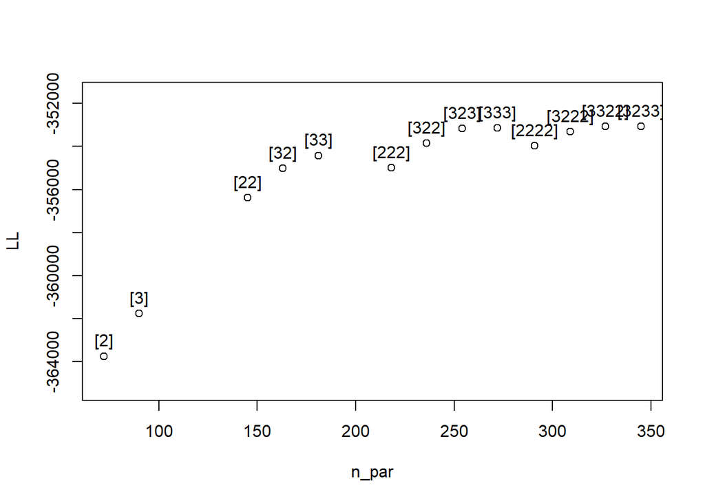

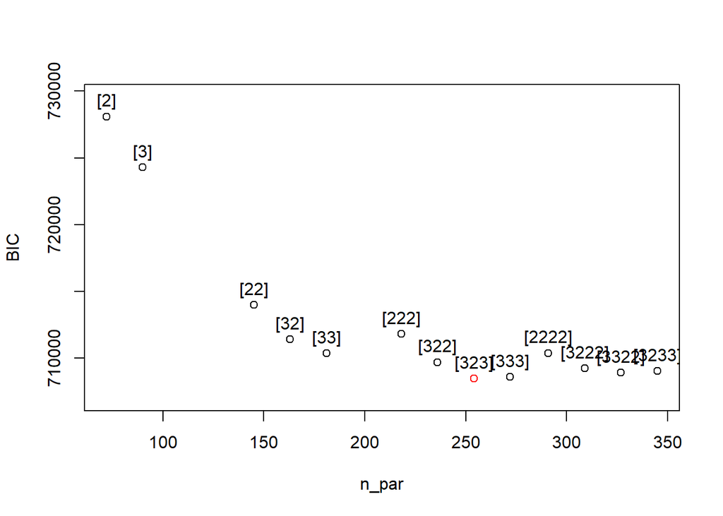

```
Use the navigation arrow in the "Plots" tab to switch
between the LL and the BIC plots.
```

```r
# BIC
plot(modelselection)
```

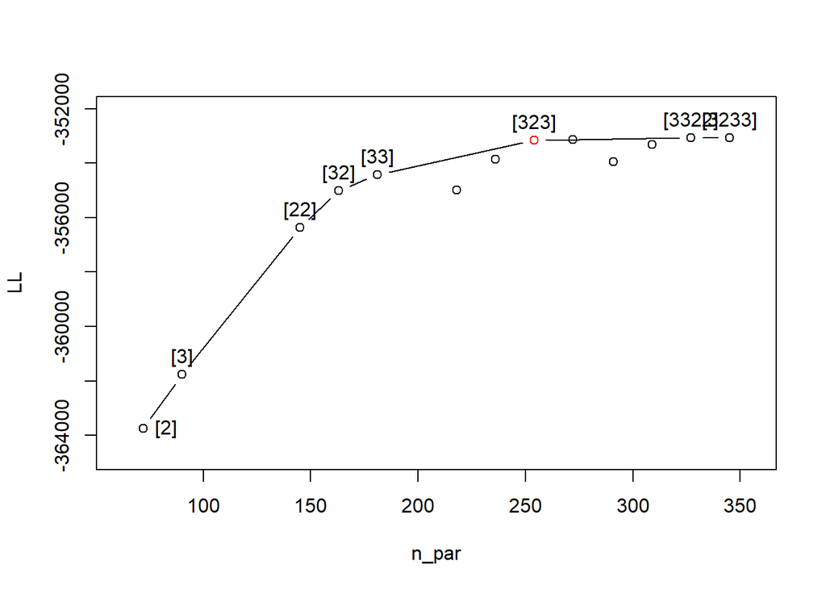

```
Models on the upper boundary of the CHull:

       n_par        LL        st
[2]       72 -363744.0        NA
[3]       90 -361759.6  1.126582
[22]     145 -356377.4  1.288490
[32]     163 -355010.3  2.319779
[33]     181 -354421.0  1.905623
[323]    254 -353166.8 13.191076
[3322]   327 -353071.7  3.812062
[3233]   345 -353065.6        NA

Selected model(s):

      n_par        LL
[323]   254 -353166.8

Note 1: The least and most complex models cannot be selected.
  Therefore, it is advisable to also visually inspect the CHull plot.

Note 2: The st value(s) of the best model(s) might be artificially
  inflated. Therefore, it is advisable to also consider the next best model(s).
```

```r
# CHull
chull_lmfa(modelselection)
```

We choose model [323] and then extract it from the results and display the parameter estimates. We can see differences in all parameters across states.

```r
# Extract the results
measurementmodel323 <- modelselection$`[323]`

# Parameter estimates
summary(measurementmodel323)
```

```
Estimation converged after 315.01 seconds and 95 iterations.

LL = -353166.81

Number of states: 3

Number of factors: [3 2 3]

-------------------------------------------------------------

Obliquely rotated standardized loadings:

              S1F1  S1F2  S1F3     S2F1  S2F2     S3F1  S3F2  S3F3
Interested    0.66  0.04  0.00     0.68  0.01     0.57 -0.01  0.02
Joyful        0.60  0.02  0.02     0.65 -0.01     0.88  0.01  0.06
Determined    0.37  0.03 -0.55     0.61  0.00     0.84  0.02 -0.01
Calm          0.37 -0.58 -0.01     0.59  0.00     0.18 -0.15  0.82
Lively        0.63  0.03  0.03     0.65  0.00     0.88 -0.01  0.01
Enthusiastic  0.65 -0.01  0.02     0.64  0.00     0.89  0.02  0.00
Relaxed       0.64  0.02  0.00     0.64  0.01     0.16 -0.14  0.85
Cheerful      0.63  0.07  0.01     0.63 -0.01     0.91  0.01  0.02
Content       0.61  0.00  0.03     0.67  0.02     0.93  0.02  0.01
Energetic     0.64 -0.01  0.00     0.63 -0.01     0.90  0.05 -0.01
Upset         0.09  0.62 -0.01     0.00  0.53     0.03  0.83 -0.03
Gloomy       -0.24  0.39  0.44    -0.01  0.53     0.02  0.82 -0.01
Sluggish      0.07 -0.01  0.73    -0.01  0.50    -0.29  0.34  0.77
Anxious       0.09  0.70 -0.02     0.00  0.52     0.05  0.79 -0.01
Bored         0.07 -0.01  0.74    -0.01  0.52     0.04  0.47 -0.04
Irritated     0.06  0.51 -0.05     0.01  0.58     0.04  0.85 -0.02
Nervous       0.08  0.73 -0.04     0.00  0.51     0.03  0.74  0.01
Listless      0.06 -0.05  0.73     0.01  0.54     0.02  0.46 -0.03


-------------------------------------------------------------

Factor correlations after oblique rotation:

S1
      F1    F2    F3
F1  1.00 -0.08 -0.24
```

[output cut: 47 more lines]

```
Calm         265.99 51.75  99.17
Lively       286.09 48.20 104.04
Enthusiastic 257.06 50.09 107.07
Relaxed      270.54 49.55  99.75
Cheerful     284.69 50.47  83.05
Content      271.52 41.15  92.38
Energetic    271.12 53.24  95.55
Upset        278.71 46.13  92.89
Gloomy       256.03 46.46  73.85
Sluggish     245.57 51.70  82.24
Anxious      276.61 45.65  87.14
Bored        253.52 47.69 103.11
Irritated    267.30 44.56  84.99
Nervous      261.57 49.30  86.21
Listless     269.07 47.29  92.10
```

We can also obtain copy of the dataset with the state-specific factor scores attached.

```r
# Obtain data with factor scores attached
ESM_fs <- factorscores_lmfa(data = ESM, model = measurementmodel323)
```

## 5.2 -Step 2

The step 2 function obtains the posterior state-membership probabilities and the model state assignments and calculates the classification error. We don’t have to look into it too much. We mainly need the object to obtain correct estimates in step 3. In brief: The R-square measure R_entropy indicates how much the measurement models differ and thus how well the states are separated (from 0 = bad separation to 1= good separation).

```r
# Obtain classifications and error
classification <- step2(data = ESM_fs, model = measurementmodel323)

# Print he results
summary(classification)
```

```
R2_entropy: 0.86

Total classification error: 0.05

Classification errors:

        S1      S2     S3
S1 2568.11    4.12  59.50
S2    2.71 1146.53  44.37
S3   50.19   89.35 811.13

Classification-error probabilities:

     S1   S2   S3
S1 0.98 0.00 0.02
S2 0.00 0.96 0.04
S3 0.05 0.09 0.85

State proportions:

  S1   S2   S3
0.55 0.26 0.19
```

The R-entropy for our example indicates good separation. This explains the small total classification error.

## 5.3 -Step 3

The step 3 function estimates the transitions between the states (conditional on covariates) by means of a continuous-time latent Markov model. We include two predictors, *having had an intervention* (yes or no) and *unpleasantness of the most unpleasant event* (0-100). The estimation for our example data took about 20 minutes. Again, you can just load the object from the data.

We first look at the Wald tests to see if the inclusion of the covariates is significant. If you don’t like p-values, you may (additionally) run alternative models (e.g., with only one covariate or no covariate) and compare the BIC values and choose the one with the lowest. For this example it didn’t make a difference but it may make a difference for other data. We decide to keep both covariates in the model.

```r
set.seed(1000)
transitionmodel <- step3(data = ESM_fs,
                         identifier = "id",
                         n_state = 3,
                         postprobs =
                           classification$classification_posteriors[,-1],
                         timeintervals  = "deltaT",
                         initialCovariates = NULL,
                         transitionCovariates =
                           c("intervention", "negativeEvent"),
                         n_starts = 25,
                         max_iterations = 1000)
```

```r
# Load the step-3 results
data("transitionmodel")

# Obtain the transition-model results
summary(transitionmodel)
```

```
Model estimation:

Estimation converged after 1266.62 seconds.

LL = -3712.4847
BIC = 7594.3966
n_par = 20

-------------------------------------------------------------

Wald tests:

                  Wald df p-value
intervention  213.3821  6       0
negativeEvent  55.7629  6       0

-------------------------------------------------------------

Parameter estimates:

                              coef   s.e. z-value p-value
initial state parameters 2 -0.1864 0.2408 -0.7741  0.4389
initial state parameters 3 -0.5479 0.2949 -1.8577  0.0632
transition parameters 1|2  -1.1725 0.3207 -3.6555  0.0003
transition parameters 1|3  -1.5951 0.4235 -3.7661  0.0002
transition parameters 2|1  -1.6011 0.4260 -3.7588  0.0002
transition parameters 2|3  -0.4188 0.4183 -1.0013  0.3167
transition parameters 3|1  -0.5761 0.2975 -1.9368  0.0528
transition parameters 3|2  -1.3186 0.7413 -1.7788  0.0753
intervention 1|2            0.6000 0.1786  3.3604  0.0008
intervention 1|3            0.3228 0.2565  1.2582  0.2083
intervention 2|1           -0.9528 0.2624 -3.6308  0.0003
intervention 2|3           -0.4081 0.2474 -1.6497  0.0990
intervention 3|1           -1.0119 0.1809 -5.5946  0.0000
intervention 3|2            0.4767 0.4931  0.9668  0.3336
negativeEvent 1|2          -0.0194 0.0057 -3.3903  0.0007
negativeEvent 1|3          -0.0096 0.0081 -1.1931  0.2328
negativeEvent 2|1           0.0153 0.0091  1.6812  0.0927
negativeEvent 2|3          -0.0071 0.0079 -0.9001  0.3681
negativeEvent 3|1           0.0104 0.0060  1.7364  0.0825
```

[output cut: 27 more lines]

```
S3 0.3909 0.1073 0.5019


Note: The probabilities are calculated for covariate scores
equal to the sample means (and a unit time interval). Use
the function probabilities() to calculate the initial state
and transition probabilities for any covariate score (and
interval) of interest.

-------------------------------------------------------------

State proportions:

    S1     S2     S3
0.5517 0.2567 0.1916
```

The parameters are difficult to interpret. It is better to obtain the probabilities for an interval of interest and different covariate values that you want to compare with. For example, keep the *negative event* score equal to it’s sample mean 49.65 and obtain the probabilities for *before having had an intervention* and for *after having had an intervention*; both for a unit interval.

Comparing the transition probabilities, we see that *having had an intervention* is related to relatively smaller probabilities of transitioning to *displeasure state* (“S1”) as well as relative smaller probabilities of staying in the *displeasure state* (“S1”).

```r
# Obtain probabilities
probabilities(model = transitionmodel,
              deltaT = 1,
              initialCovariateScores = NULL,
              transitionCovariateScores = c(0,49.65))
```

```
1. Initial state probabilities:

(no covariates defined)

  S1   S2   S3
0.42 0.34 0.24

2. Transition probabilities:

interval length: 1
intervention score: 0
negativeEvent score: 49.65

     S1   S2   S3
S1 0.84 0.07 0.08
S2 0.37 0.44 0.19
S3 0.54 0.08 0.39
```

```r
probabilities(model = transitionmodel,
              deltaT = 1,
              initialCovariateScores = NULL,
              transitionCovariateScores = c(1,49.65))
```

```
1. Initial state probabilities:

(no covariates defined)

  S1   S2   S3
0.42 0.34 0.24

2. Transition probabilities:

interval length: 1
intervention score: 1
negativeEvent score: 49.65

     S1   S2   S3
S1 0.71 0.16 0.13
S2 0.14 0.66 0.20
S3 0.23 0.15 0.61
```

We can now obtain a copy of our dataset with the final state assignments attached.

```r
# Attach updates classifications to data
ESM_fs_cl <- transitionmodel$data
```

To obtain an initial idea of how subjects transition, we can inspect transition plots (here only for four subjects).

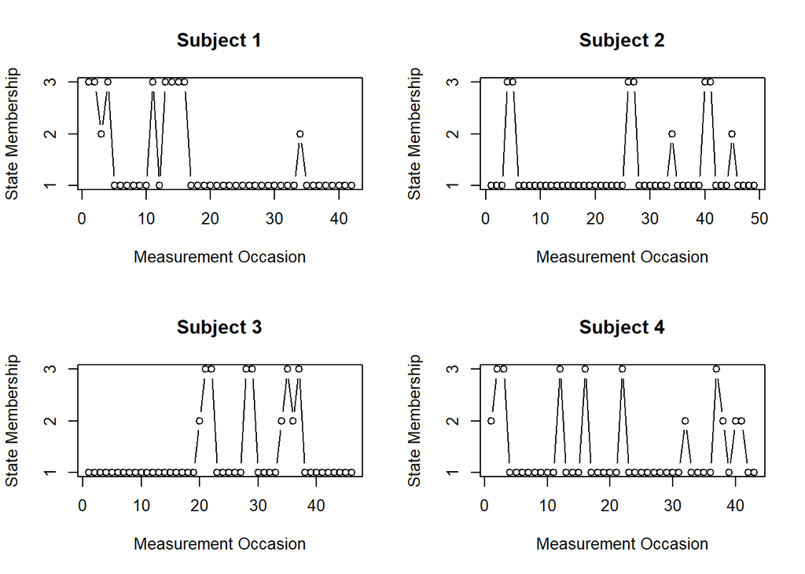

```r
# Obtain transition plots
layout(matrix(c(1,3,2,4), nrow = 2, ncol = 2))
for(i in 1:4) plot(transitionmodel, identifier = "id", id = i)
```

Finally, we can get some insights into for which subjects longitudinal invariance holds, and for which subjects the model is also invariant across subjects. In other words, we can get insight into which subjects stay in the same state for their entire participation, and if there are subjects that are in the same permanent state. If there were subjects for which longitudinal invariance holds, they would be listed under their permanent state membership in the output below. For subjects who are in the same permanent state, invariance holds across all observations. However, the NA’s indicate that this longitudinal invariance doesn’t apply to any of the subjects.

```r
# Obtain invariance information
invariance(model = transitionmodel, identifier = "id")
```

```
S1
NA

S2
NA

S3
NA
```

## 5.4 -Summary of the findings

1. How many MMs are underlying our ILD?
- *Three MMs are underlying the example data.*
2. How do the MMs differ?
- *The number and nature of the factors differ, implying that configural invariance is violated for our example data. More specifically, we found three states (a displeasure, a neutral, and a pleasure state) that all contained a positive affect and a negative affect (or distress) factor, but the displeasure state was additionally characterized by a drive factor and the neutral state by a serenity factor.*
3. How do subjects transition between the MMs over time, and is this related to time- or subject-specific covariates?
- *Most subjects started in the displeasure state. The probabilities of staying in a state were generally higher than transitioning to another state (especially for subjects in the displeasure state). Transitions to the displeasure state were most likely, especially when experiencing negative events. After receiving an intervention, the probabilities of transitioning to and staying in the neutral or pleasure state increased.*
4. For which subjects does longitudinal invariance hold, and for which of these subjects does invariance hold across subjects?
- *Longitudinal invariance does not hold for any of the subjects and, therefore, neither does invariance across subjects.*

# 6 TL;DR, just give me the code!

```r
# Install the packages if you don't have them yet
install.packages("semTools")
install.packages("devtools")

# Trick to install older igraph version
require(devtools)
install_version("igraph", version = "1.3.0", repos = "http://cran.us.r-project.org")

# Continue installing lmfa
devtools::install_github("leonievm/lmfa")

# Trick if something fails with semTools:
detach("package:semTools", unload = TRUE)
detach("package:lavaan", unload = TRUE)

# Load packages
library(semTools)
library(devtools)
library(lmfa)

# Read the workspace we will need for this session
load("Workspace_IOPS.RData")

# Read data that is part of the ESM package
data("ESM")

CM_factor_T1 <- '

# Define the latent factors.
CM_1 =~ NA*T1_CM_01 +lambda1*T1_CM_01 + T1_CM_02 + T1_CM_03 + T1_CM_04 +
        T1_CM_05 + T1_CM_06 + T1_CM_07 + T1_CM_08

# Intercepts
T1_CM_01 ~ i1*1
T1_CM_02 ~ 1
T1_CM_03 ~ 1
T1_CM_04 ~ 1
T1_CM_05 ~ 1
T1_CM_06 ~ 1
T1_CM_07 ~ 1
T1_CM_08 ~ 1

# Unique Variances
T1_CM_01 ~~ T1_CM_01
T1_CM_02 ~~ T1_CM_02
T1_CM_03 ~~ T1_CM_03
T1_CM_04 ~~ T1_CM_04
T1_CM_05 ~~ T1_CM_05
T1_CM_06 ~~ T1_CM_06
T1_CM_07 ~~ T1_CM_07
T1_CM_08 ~~ T1_CM_08

# Latent Variable Means
CM_1 ~ 0*1

# Latent Variable Variances and Covariance
CM_1 ~~ 1*CM_1
'
# Model fitting
fit_CM_T1 <- cfa(CM_factor_T1, data = Data_Cross_Panel, mimic = "mplus")

# Getting the results
summary(fit_CM_T1, fit.measures = TRUE)

# Generate code for checking configural invariance between groups
mod.configural  <- semTools::measEq.syntax(configural.model = CM_factor_T1,
                                         data = Data_Cross_Panel,
                                         group = "Gender", mimic = "mplus")

# Inspect the generated code
cat(as.character(mod.configural))
# Generate code for checking invariance of loadings
mod.loadings  <- semTools::measEq.syntax(configural.model = CM_factor_T1,
                                           data = Data_Cross_Panel,
                                           group.equal = c("loadings"),
                                           group = "Gender", mimic = "mplus")

# Inspect the generated code
cat(as.character(mod.loadings))
# Generate code for checking invariance of intercepts and loadings
mod.int.load <- semTools::measEq.syntax(configural.model = CM_factor_T1,
                                           data = Data_Cross_Panel,
                                           group.equal = c("intercepts",
                                                           "loadings"),
                                           group = "Gender", mimic = "mplus")

# Inspect the generated code
cat(as.character(mod.int.load))
# Fit the configural invariance model
fit.configural <- cfa(as.character(mod.configural), data = Data_Cross_Panel,
                      group = "Gender", mimic = "mplus")

# Fit the loading invariance model
fit.loadings <- cfa(as.character(mod.loadings), data = Data_Cross_Panel,
                    group = "Gender", mimic = "mplus")

# Fit the intercept and loading invariance model
fit.int.load <- cfa(as.character(mod.int.load), data = Data_Cross_Panel,
                    group = "Gender", mimic = "mplus")

# Check model fit using CFI, RMSEA, SRMR, and Chi-square again
summary(fit.configural, fit.measures = TRUE)
Check.Load <- semTools::compareFit(fit.configural, fit.loadings)
summary(Check.Load)

Check.Int <- semTools::compareFit(fit.loadings, fit.int.load)
summary(Check.Int)

# Difference in groups in intercepts
parameterEstimates(fit.loadings)[9:16,7] -
  parameterEstimates(fit.loadings)[35:42,7]

which(
  (parameterEstimates(fit.loadings)[9:16,7] -
     parameterEstimates(fit.loadings)[35:42,7])
  == min(parameterEstimates(fit.loadings)[9:16,7] -
           parameterEstimates(fit.loadings)[35:42,7]))

mod.intercepts.part <- semTools::measEq.syntax(configural.model= CM_factor_T1,
                                          data = Data_Cross_Panel,
                                          group.equal = c("loadings",
                                                          "intercepts"),
                                          group.partial = c("T1_CM_05 ~ 1"),
                                          group ="Gender", mimic = "mplus")

# Inspect the generated code
cat(as.character(mod.intercepts.part))

# Fit the intercept invariance model
fit.intercepts.part <- cfa(as.character(mod.intercepts.part), data = Data_Cross_Panel,
                      group ="Gender", mimic = "mplus")


Check.Int.Part <- semTools::compareFit(fit.loadings, fit.intercepts.part)
summary(Check.Int.Part)


# Calculate Reliability for the final model
compRelSEM(fit.intercepts.part)

LI_CM <- '

# Define the latent factors.
CM_1 =~ NA*T1_CM_01 + 1*T1_CM_01 + T1_CM_02 + T1_CM_03 + T1_CM_04 + T1_CM_05
+ T1_CM_06 + T1_CM_07 + T1_CM_08

CM_2 =~ NA*T2_CM_01 + 1*T2_CM_01 + T2_CM_02 + T2_CM_03 + T2_CM_04 + T2_CM_05
+ T2_CM_06 + T2_CM_07 + T2_CM_08

CM_3 =~ NA*T3_CM_01 + 1*T3_CM_01 + T3_CM_02 + T3_CM_03 + T3_CM_04 + T3_CM_05
+ T3_CM_06 + T3_CM_07 + T3_CM_08

# Intercepts
T1_CM_01 ~ 1
T1_CM_02 ~ 1
T1_CM_03 ~ 1
T1_CM_04 ~ 1
T1_CM_05 ~ 1
T1_CM_06 ~ 1
T1_CM_07 ~ 1
T1_CM_08 ~ 1

T2_CM_01 ~ 1
T2_CM_02 ~ 1
T2_CM_03 ~ 1
T2_CM_04 ~ 1
T2_CM_05 ~ 1
T2_CM_06 ~ 1
T2_CM_07 ~ 1
T2_CM_08 ~ 1

T3_CM_01 ~ 1
T3_CM_02 ~ 1
T3_CM_03 ~ 1
T3_CM_04 ~ 1
T3_CM_05 ~ 1
T3_CM_06 ~ 1
T3_CM_07 ~ 1
T3_CM_08 ~ 1

# Unique Variances
T1_CM_01 ~~ T1_CM_01
T1_CM_02 ~~ T1_CM_02
T1_CM_03 ~~ T1_CM_03
T1_CM_04 ~~ T1_CM_04
T1_CM_05 ~~ T1_CM_05
T1_CM_06 ~~ T1_CM_06
T1_CM_07 ~~ T1_CM_07
T1_CM_08 ~~ T1_CM_08

T2_CM_01 ~~ T2_CM_01
T2_CM_02 ~~ T2_CM_02
T2_CM_03 ~~ T2_CM_03
T2_CM_04 ~~ T2_CM_04
T2_CM_05 ~~ T2_CM_05
T2_CM_06 ~~ T2_CM_06
T2_CM_07 ~~ T2_CM_07
T2_CM_08 ~~ T2_CM_08

T3_CM_01 ~~ T3_CM_01
T3_CM_02 ~~ T3_CM_02
T3_CM_03 ~~ T3_CM_03
T3_CM_04 ~~ T3_CM_04
T3_CM_05 ~~ T3_CM_05
T3_CM_06 ~~ T3_CM_06
T3_CM_07 ~~ T3_CM_07
T3_CM_08 ~~ T3_CM_08

# Latent Variable Means
CM_1 ~ 0*1
CM_2 ~ 0*1
CM_3 ~ 0*1

# Latent Variable Variances and Covariance
CM_1 ~~ 1*CM_1
CM_2 ~~ 1*CM_2
CM_3 ~~ 1*CM_3
'
```

```r
# Model fitting
fit_CM_Long <- cfa(LI_CM, data = Data_Cross_Panel, mimic = "mplus")

# Getting the results
summary(fit_CM_Long, fit.measures = TRUE)

# Generate code for checking configural invariance across time

longFacNames <- list(CM = c("CM_1","CM_2","CM_3"))

mod.configural.long <-semTools::measEq.syntax(LI_CM,
                                     longFacNames = longFacNames,
                                     data = Data_Cross_Panel, missing = "fiml")
# Now we use a new argument longFacNames. For details, see ?measEq.syntax

# Inspect the generated code
cat(as.character(mod.configural.long))

fit.configural.long <- lavaan::cfa(as.character(mod.configural.long),
                              data = Data_Cross_Panel,
                              fixed.x = FALSE)

# Check model fit using CFI, RMSEA, SRMR, and Chi-square again
summary(fit.configural.long, fit.measures = TRUE)

# Obtain the modification indices
MIs <- modindices(fit.configural.long)

# Show the first 30
head(MIs[order(MIs$mi, decreasing = TRUE), 1:4], n = 30)
LI_CM2 <- '

# Define the latent factors.
CM_1 =~ NA*T1_CM_01 + 1*T1_CM_01 + T1_CM_02 + T1_CM_03 + T1_CM_04 + T1_CM_05 + T1_CM_06 + T1_CM_07 + T1_CM_08
CM_2 =~ NA*T2_CM_01 + 1*T2_CM_01 + T2_CM_02 + T2_CM_03 + T2_CM_04 + T2_CM_05 + T2_CM_06 + T2_CM_07 + T2_CM_08
CM_3 =~ NA*T3_CM_01 + 1*T3_CM_01 + T3_CM_02 + T3_CM_03 + T3_CM_04 + T3_CM_05 + T3_CM_06 + T3_CM_07 + T3_CM_08

# Intercepts
T1_CM_01 ~ 1
T1_CM_02 ~ 1
T1_CM_03 ~ 1
T1_CM_04 ~ 1
T1_CM_05 ~ 1
T1_CM_06 ~ 1
T1_CM_07 ~ 1
T1_CM_08 ~ 1

T2_CM_01 ~ 1
T2_CM_02 ~ 1
T2_CM_03 ~ 1
T2_CM_04 ~ 1
T2_CM_05 ~ 1
T2_CM_06 ~ 1
T2_CM_07 ~ 1
T2_CM_08 ~ 1

T3_CM_01 ~ 1
T3_CM_02 ~ 1
T3_CM_03 ~ 1
T3_CM_04 ~ 1
T3_CM_05 ~ 1
T3_CM_06 ~ 1
T3_CM_07 ~ 1
T3_CM_08 ~ 1

# Unique Variances
T1_CM_01 ~~ T1_CM_01
T1_CM_02 ~~ T1_CM_02
T1_CM_03 ~~ T1_CM_03
T1_CM_04 ~~ T1_CM_04
T1_CM_05 ~~ T1_CM_05
T1_CM_06 ~~ T1_CM_06
T1_CM_07 ~~ T1_CM_07
T1_CM_08 ~~ T1_CM_08

T2_CM_01 ~~ T2_CM_01
T2_CM_02 ~~ T2_CM_02
T2_CM_03 ~~ T2_CM_03
T2_CM_04 ~~ T2_CM_04
T2_CM_05 ~~ T2_CM_05
T2_CM_06 ~~ T2_CM_06
T2_CM_07 ~~ T2_CM_07
T2_CM_08 ~~ T2_CM_08

T3_CM_01 ~~ T3_CM_01
T3_CM_02 ~~ T3_CM_02
T3_CM_03 ~~ T3_CM_03
T3_CM_04 ~~ T3_CM_04
T3_CM_05 ~~ T3_CM_05
T3_CM_06 ~~ T3_CM_06
T3_CM_07 ~~ T3_CM_07
T3_CM_08 ~~ T3_CM_08

# Latent Variable Means
CM_1 ~ 0*1
CM_2 ~ 0*1
CM_3 ~ 0*1

# Latent Variable Variances and Covariance
CM_1 ~~ 1*CM_1
CM_2 ~~ 1*CM_2
CM_3 ~~ 1*CM_3


# Residual Covariances
T1_CM_03 ~~ T1_CM_06
T2_CM_03 ~~ T2_CM_06
T3_CM_03 ~~ T3_CM_06
'
# Generate code and inspect it
mod.configural.long2 <-semTools::measEq.syntax(LI_CM2,
                                              longFacNames = longFacNames,
                                              data = Data_Cross_Panel, missing = "fiml")
cat(as.character(mod.configural.long2))

# Model fitting
fit.configural.long2 <- lavaan::cfa(as.character(mod.configural.long2),
                              data = Data_Cross_Panel,
                              fixed.x = FALSE)
# Check model fit using CFI, RMSEA, SRMR, and Chi-square again
summary(fit.configural.long2, fit.measures = TRUE)
# Obtain the modification indices
MIs2 <- modindices(fit.configural.long2)

# Show the first 30
head(MIs2[order(MIs2$mi, decreasing = TRUE), 1:4], n = 30)
LI_CM3 <- '

# Define the latent factors.
CM_1 =~ NA*T1_CM_01 + 1*T1_CM_01 + T1_CM_02 + T1_CM_03 + T1_CM_04 + T1_CM_05
+ T1_CM_06 + T1_CM_07 + T1_CM_08
CM_2 =~ NA*T2_CM_01 + 1*T2_CM_01 + T2_CM_02 + T2_CM_03 + T2_CM_04 + T2_CM_05
+ T2_CM_06 + T2_CM_07 + T2_CM_08
CM_3 =~ NA*T3_CM_01 + 1*T3_CM_01 + T3_CM_02 + T3_CM_03 + T3_CM_04 + T3_CM_05
+ T3_CM_06 + T3_CM_07 + T3_CM_08

# Intercepts
T1_CM_01 ~ 1
T1_CM_02 ~ 1
T1_CM_03 ~ 1
T1_CM_04 ~ 1
T1_CM_05 ~ 1
T1_CM_06 ~ 1
T1_CM_07 ~ 1
T1_CM_08 ~ 1

T2_CM_01 ~ 1
T2_CM_02 ~ 1
T2_CM_03 ~ 1
T2_CM_04 ~ 1
T2_CM_05 ~ 1
T2_CM_06 ~ 1
T2_CM_07 ~ 1
T2_CM_08 ~ 1

T3_CM_01 ~ 1
T3_CM_02 ~ 1
T3_CM_03 ~ 1
T3_CM_04 ~ 1
T3_CM_05 ~ 1
T3_CM_06 ~ 1
T3_CM_07 ~ 1
T3_CM_08 ~ 1

# Unique Variances
T1_CM_01 ~~ T1_CM_01
T1_CM_02 ~~ T1_CM_02
T1_CM_03 ~~ T1_CM_03
T1_CM_04 ~~ T1_CM_04
T1_CM_05 ~~ T1_CM_05
T1_CM_06 ~~ T1_CM_06
T1_CM_07 ~~ T1_CM_07
T1_CM_08 ~~ T1_CM_08

T2_CM_01 ~~ T2_CM_01
T2_CM_02 ~~ T2_CM_02
T2_CM_03 ~~ T2_CM_03
T2_CM_04 ~~ T2_CM_04
T2_CM_05 ~~ T2_CM_05
T2_CM_06 ~~ T2_CM_06
T2_CM_07 ~~ T2_CM_07
T2_CM_08 ~~ T2_CM_08

T3_CM_01 ~~ T3_CM_01
T3_CM_02 ~~ T3_CM_02
T3_CM_03 ~~ T3_CM_03
T3_CM_04 ~~ T3_CM_04
T3_CM_05 ~~ T3_CM_05
T3_CM_06 ~~ T3_CM_06
T3_CM_07 ~~ T3_CM_07
T3_CM_08 ~~ T3_CM_08

# Latent Variable Means
CM_1 ~ 0*1
CM_2 ~ 0*1
CM_3 ~ 0*1

# Latent Variable Variances and Covariance
CM_1 ~~ 1*CM_1
CM_2 ~~ 1*CM_2
CM_3 ~~ 1*CM_3


# Residual Covariances
T1_CM_03 ~~ T1_CM_06
T2_CM_03 ~~ T2_CM_06
T3_CM_03 ~~ T3_CM_06

T1_CM_01 ~~ T1_CM_02
T2_CM_01 ~~ T2_CM_02
T3_CM_01 ~~ T3_CM_02

'
# Generate code and inspect it
mod.configural.long3 <-semTools::measEq.syntax(LI_CM3,
                                               longFacNames = longFacNames,
                                               data = Data_Cross_Panel, missing = "fiml")
cat(as.character(mod.configural.long3))

# Model fitting
fit.configural.long3 <- lavaan::cfa(as.character(mod.configural.long3),
                               data = Data_Cross_Panel,
                               fixed.x = FALSE)
# Check model fit using CFI, RMSEA, SRMR, and Chi-square again
summary(fit.configural.long3, fit.measures = TRUE)
LI_CM4 <- '

# Define the latent factors.
CM_1 =~ NA*T1_CM_01 + 1*T1_CM_01 + T1_CM_02 + T1_CM_04 + T1_CM_05 + T1_CM_06
+ T1_CM_07 + T1_CM_08
CM_2 =~ NA*T2_CM_01 + 1*T2_CM_01 + T2_CM_02 + T2_CM_04 + T2_CM_05 + T2_CM_06
+ T2_CM_07 + T2_CM_08
CM_3 =~ NA*T3_CM_01 + 1*T3_CM_01 + T3_CM_02 + T3_CM_04 + T3_CM_05 + T3_CM_06
+ T3_CM_07 + T3_CM_08

# Intercepts
T1_CM_01 ~ 1
T1_CM_02 ~ 1
T1_CM_04 ~ 1
T1_CM_05 ~ 1
T1_CM_06 ~ 1
T1_CM_07 ~ 1
T1_CM_08 ~ 1

T2_CM_01 ~ 1
T2_CM_02 ~ 1
T2_CM_04 ~ 1
T2_CM_05 ~ 1
T2_CM_06 ~ 1
T2_CM_07 ~ 1
T2_CM_08 ~ 1

T3_CM_01 ~ 1
T3_CM_02 ~ 1
T3_CM_04 ~ 1
T3_CM_05 ~ 1
T3_CM_06 ~ 1
T3_CM_07 ~ 1
T3_CM_08 ~ 1
```

```r
# Unique Variances
T1_CM_01 ~~ T1_CM_01
T1_CM_02 ~~ T1_CM_02
T1_CM_04 ~~ T1_CM_04
T1_CM_05 ~~ T1_CM_05
T1_CM_06 ~~ T1_CM_06
T1_CM_07 ~~ T1_CM_07
T1_CM_08 ~~ T1_CM_08

T2_CM_01 ~~ T2_CM_01
T2_CM_02 ~~ T2_CM_02
T2_CM_04 ~~ T2_CM_04
T2_CM_05 ~~ T2_CM_05
T2_CM_06 ~~ T2_CM_06
T2_CM_07 ~~ T2_CM_07
T2_CM_08 ~~ T2_CM_08

T3_CM_01 ~~ T3_CM_01
T3_CM_02 ~~ T3_CM_02
T3_CM_04 ~~ T3_CM_04
T3_CM_05 ~~ T3_CM_05
T3_CM_06 ~~ T3_CM_06
T3_CM_07 ~~ T3_CM_07
T3_CM_08 ~~ T3_CM_08

# Latent Variable Means
CM_1 ~ 0*1
CM_2 ~ 0*1
CM_3 ~ 0*1

# Latent Variable Variances and Covariance
CM_1 ~~ 1*CM_1
CM_2 ~~ 1*CM_2
CM_3 ~~ 1*CM_3
'
# Generate code and inspect it
mod.configural.long4 <- semTools::measEq.syntax(LI_CM4,
                                               longFacNames = longFacNames,
                                               data = Data_Cross_Panel, missing = "fiml")
cat(as.character(mod.configural.long4))

# Model fitting
fit.configural.long4 <- lavaan::cfa(as.character(mod.configural.long4),
                               data = Data_Cross_Panel,
                               fixed.x = FALSE)
# Check model fit using CFI, RMSEA, SRMR, and Chi-square again
summary(fit.configural.long4, fit.measures=T)
LI_CM5 <- '

# Define the latent factors.
CM_1 =~ NA*T1_CM_02 + T1_CM_02 + T1_CM_04 + T1_CM_05 + T1_CM_06 + T1_CM_07
+ T1_CM_08
CM_2 =~ NA*T2_CM_02 + T2_CM_02 + T2_CM_04 + T2_CM_05 + T2_CM_06 + T2_CM_07
+ T2_CM_08
CM_3 =~ NA*T3_CM_02 + T3_CM_02 + T3_CM_04 + T3_CM_05 + T3_CM_06 + T3_CM_07
+ T3_CM_08

# Intercepts
T1_CM_02 ~ 1
T1_CM_04 ~ 1
T1_CM_05 ~ 1
T1_CM_06 ~ 1
T1_CM_07 ~ 1
T1_CM_08 ~ 1

T2_CM_02 ~ 1
T2_CM_04 ~ 1
T2_CM_05 ~ 1
T2_CM_06 ~ 1
T2_CM_07 ~ 1
T2_CM_08 ~ 1

T3_CM_02 ~ 1
T3_CM_04 ~ 1
T3_CM_05 ~ 1
T3_CM_06 ~ 1
T3_CM_07 ~ 1
T3_CM_08 ~ 1

# Unique Variances
T1_CM_02 ~~ T1_CM_02
T1_CM_04 ~~ T1_CM_04
T1_CM_05 ~~ T1_CM_05
T1_CM_06 ~~ T1_CM_06
T1_CM_07 ~~ T1_CM_07
T1_CM_08 ~~ T1_CM_08

T2_CM_02 ~~ T2_CM_02
T2_CM_04 ~~ T2_CM_04
T2_CM_05 ~~ T2_CM_05
T2_CM_06 ~~ T2_CM_06
T2_CM_07 ~~ T2_CM_07
T2_CM_08 ~~ T2_CM_08

T3_CM_02 ~~ T3_CM_02
T3_CM_04 ~~ T3_CM_04
T3_CM_05 ~~ T3_CM_05
T3_CM_06 ~~ T3_CM_06
T3_CM_07 ~~ T3_CM_07
T3_CM_08 ~~ T3_CM_08

# Latent Variable Means
CM_1 ~ 0*1
CM_2 ~ 0*1
CM_3 ~ 0*1

# Latent Variable Variances and Covariance
CM_1 ~~ 1*CM_1
CM_2 ~~ 1*CM_2
CM_3 ~~ 1*CM_3
'
# Generate code and inspect it
mod.configural.long5 <-semTools::measEq.syntax(LI_CM5,
                                               longFacNames = longFacNames,
                                               data = Data_Cross_Panel, missing = "fiml")
cat(as.character(mod.configural.long5))

# Model fitting
fit.configural.long5 <- lavaan::cfa(as.character(mod.configural.long5),
                               data = Data_Cross_Panel,
                               fixed.x = FALSE)
# Check model fit using CFI, RMSEA, SRMR, and Chi-square again
summary(fit.configural.long5, fit.measures=T)
LI_CM6 <- '

# Define the latent factors.
CM_1 =~ NA*T1_CM_02 + T1_CM_02 + T1_CM_04 + T1_CM_05 + T1_CM_07 + T1_CM_08
CM_2 =~ NA*T2_CM_02 + T2_CM_02 + T2_CM_04 + T2_CM_05 + T2_CM_07 + T2_CM_08
CM_3 =~ NA*T3_CM_02 + T3_CM_02 + T3_CM_04 + T3_CM_05 + T3_CM_07 + T3_CM_08

# Intercepts
T1_CM_02 ~ 1
T1_CM_04 ~ 1
T1_CM_05 ~ 1
T1_CM_07 ~ 1
T1_CM_08 ~ 1

T2_CM_02 ~ 1
T2_CM_04 ~ 1
T2_CM_05 ~ 1
T2_CM_07 ~ 1
T2_CM_08 ~ 1

T3_CM_02 ~ 1
T3_CM_04 ~ 1
T3_CM_05 ~ 1
T3_CM_07 ~ 1
T3_CM_08 ~ 1

# Unique Variances
T1_CM_02 ~~ T1_CM_02
T1_CM_04 ~~ T1_CM_04
T1_CM_05 ~~ T1_CM_05
T1_CM_07 ~~ T1_CM_07
T1_CM_08 ~~ T1_CM_08

T2_CM_02 ~~ T2_CM_02
T2_CM_04 ~~ T2_CM_04
T2_CM_05 ~~ T2_CM_05
T2_CM_07 ~~ T2_CM_07
T2_CM_08 ~~ T2_CM_08

T3_CM_02 ~~ T3_CM_02
T3_CM_04 ~~ T3_CM_04
T3_CM_05 ~~ T3_CM_05
T3_CM_07 ~~ T3_CM_07
T3_CM_08 ~~ T3_CM_08

# Latent Variable Means
CM_1 ~ 0*1
CM_2 ~ 0*1
CM_3 ~ 0*1

# Latent Variable Variances and Covariance
CM_1 ~~ 1*CM_1
CM_2 ~~ 1*CM_2
CM_3 ~~ 1*CM_3
'
# Generate code and inspect it
mod.configural.long6 <-semTools::measEq.syntax(LI_CM6,
                                               longFacNames = longFacNames,
                                               data=Data_Cross_Panel, missing = "fiml")
cat(as.character(mod.configural.long6))

# Model fitting
fit.configural.long6 <- lavaan::cfa(as.character(mod.configural.long6),
                               data = Data_Cross_Panel,
                               fixed.x = FALSE)
# Check model fit using CFI, RMSEA, SRMR, and Chi-square again
summary(fit.configural.long6, fit.measures = TRUE)
# Generate code for checking longitudinal invariance of loadings

mod.loadings.long <-semTools::measEq.syntax(LI_CM6, longFacNames = longFacNames,
                                     long.equal = "loadings", data=Data_Cross_Panel,
                                     missing="fiml")

# Inspect the generated code
cat(as.character(mod.loadings.long))
# Generate code for checking longitudinal invariance of intercepts and loadings
mod.int.load.long <-semTools::measEq.syntax(LI_CM6,
                                              longFacNames = longFacNames,
                                              long.equal = c("intercepts",
                                                             "loadings"),
                                              data=Data_Cross_Panel, missing="fiml")

# Inspect the generated code
cat(as.character(mod.int.load.long))
# Fit the loading invariance model
fit.loading.long <- lavaan::cfa(as.character(mod.loadings.long),
                               data = Data_Cross_Panel,
                               fixed.x=FALSE)

# Fit the intercept invariance model
fit.int.load.long <- lavaan::cfa(as.character(mod.int.load.long),
                                  data = Data_Cross_Panel,
                                  fixed.x=FALSE)

Check.Load.Long <- semTools::compareFit(fit.configural.long6, fit.loading.long)
summary(Check.Load.Long)

Check.Int.Load.Long <- semTools::compareFit(fit.loading.long,
                                            fit.int.load.long)
summary(Check.Int.Load.Long)

# Calculate Reliability for the final model
compRelSEM(fit.int.load.long)
```

```r
Mutlilevel_factor <- '
# Define the latent factors on level 1.
level: 1
  DG_1 =~ NA*anything +lambda1*anything + fail + fault + smart +
        mistakes + hire + looks

# Intercepts
  anything ~ i1*1
  fail ~ 1
  fault ~ 1
  smart ~ 1
  mistakes ~ 1
  hire ~ 1
  looks ~ 1

# Unique Variances
  anything ~~ anything
  fail ~~ fail
  fault ~~ fault
  smart ~~ smart
  mistakes ~~ mistakes
  hire ~~ hire
  looks ~~ looks


# Latent Variable Means
  DG_1 ~ 0*1

# Latent Variable Variances and Covariance
  DG_1 ~~ 1*DG_1

# Define the latent factors on level 2.
level: 2

  DG_1 =~ NA*anything +lambda1*anything + fail + fault + smart +
        mistakes + hire + looks

# Latent Variable Means
  DG_1 ~ 0*1

# Latent Variable Variances and Covariance
  DG_1 ~~ 1*DG_1
'
# Model fitting
fit.multilevel <- cfa(model = Mutlilevel_factor, data = Data_ILD,
                      cluster = "id")

# Check model fit using CFI, RMSEA, SRMR, and Chi-square again
summary(fit.multilevel, fit.measures = TRUE)

lavInspect(fit.multilevel, "icc")

lavInspect(fit.multilevel, "h1")
# Obtain the modification indices
MIsML <- modindices(fit.multilevel)

# Show the first 20
head(MIsML[order(MIsML$mi, decreasing = TRUE), 1:7], n = 30)
Mutlilevel_factor2 <- '
# Define the latent factors on level 1.
level: 1
  DG_1 =~ NA*anything +lambda1*anything + fail + fault + smart +
        mistakes + hire + looks

# Intercepts
  anything ~ i1*1
  fail ~ 1
  fault ~ 1
  smart ~ 1
  mistakes ~ 1
  hire ~ 1
  looks ~ 1

# Unique Variances
  anything ~~ anything
  fail ~~ fail
  fault ~~ fault
  smart ~~ smart
  mistakes ~~ mistakes
  hire ~~ hire
  looks ~~ looks


# Latent Variable Means
  DG_1 ~ 0*1

# Latent Variable Variances and Covariance
  DG_1 ~~ 1*DG_1

# Residual Covariances

 anything ~~ fail

# Define the latent factors on level 2.
level: 2

  DG_1 =~ NA*anything +lambda1*anything + fail + fault + smart +
        mistakes + hire + looks

# Latent Variable Means
  DG_1 ~ 0*1

# Latent Variable Variances and Covariance
  DG_1 ~~ 1*DG_1
'
# Model fitting
fit.multilevel2 <- cfa(model = Mutlilevel_factor2, data = Data_ILD,
                      cluster = "id")
summary(fit.multilevel2, fit.measures=T)
# Calculate Reliability per level
compRelSEM(fit.multilevel2)

# Don't run this; it takes three hours
set.seed(1000)
modelselection <- step1(data = ESM,
                        indicators = c(
                          "Interested","Joyful","Determined","Calm","Lively",
                          "Enthusiastic","Relaxed","Cheerful","Content",
                          "Energetic","Upset","Gloomy","Sluggish","Anxious",
                          "Bored","Irritated","Nervous","Listless"),
                        modelselection = TRUE,
                        n_state_range = 1:4,
                        n_fact_range = 2:3,
                        n_starts = 25,
                        max_iterations = 1000)

# Load the step-1 results
data("modelselection")

# Obtain the model-selection results
summary(modelselection)

# BIC
plot(modelselection)

# CHull
chull_lmfa(modelselection)

# Extract the results
measurementmodel323 <- modelselection$`[323]`

# Parameter estimates
summary(measurementmodel323)

# Obtain data with factor scores attached
ESM_fs <- factorscores_lmfa(data = ESM, model = measurementmodel323)

# Obtain classifications and error
classification <- step2(data = ESM_fs, model = measurementmodel323)

# Print he results
summary(classification)

set.seed(1000)
transitionmodel <- step3(data = ESM_fs,
                         identifier = "id",
                         n_state = 3,
                         postprobs =
                           classification$classification_posteriors[,-1],
                         timeintervals  = "deltaT",
                         initialCovariates = NULL,
                         transitionCovariates =
                           c("intervention", "negativeEvent"),
                         n_starts = 25,
                         max_iterations = 1000)
# Load the step-3 results
data("transitionmodel")

# Obtain the transition-model results
summary(transitionmodel)
# Obtain probabilities
probabilities(model = transitionmodel,
              deltaT = 1,
              initialCovariateScores = NULL,
              transitionCovariateScores = c(0,49.65))

probabilities(model = transitionmodel,
              deltaT = 1,
              initialCovariateScores = NULL,
              transitionCovariateScores = c(1,49.65))
# Attach updates classifications to data
ESM_fs_cl <- transitionmodel$data

# Obtain transition plots
layout(matrix(c(1,3,2,4), nrow = 2, ncol = 2))
for(i in 1:4) plot(transitionmodel, identifier = "id", id = i)

# Obtain invariance information
invariance(model = transitionmodel, identifier = "id")
```